# Retracing the Path of Personal Network Curation into Social Media

Joseph B. Bayer

School of Communication, The Ohio State University, Columbus, OH  
Corresponding Author  
bayer.66@osu.edu

Matthew D. Sweitzer

School of Communication, The Ohio State University, Columbus, OH  
Sandia National Laboratories, Albuquerque, NM

Haoyan Xiang

Translational Data Analytics Institute, The Ohio State University, Columbus, OH

Sriram Mohan

Department of Communication and Media, University of Michigan, Ann Arbor, MI

Ellen Meyers

Department of Anthropology, Cambridge University, Cambridge, UK

# Study 1

### Human content coding

```r
library(irr)
library(readxl)
library(knitr)
##read in data
rater <- read.csv("rater.csv")
rater1 = c(3,7,12,16,21,25,29,33,37,41,45,49)
rater2=c(4,8,13,17,22,26,30,34,38,42,46,50)
rater3=c(9,18)
```

We will first calculate Krippendorff’s alpha reliability for nominal variables.

```r
##Create vector for nomial krippendorff alpha
nominal.alpha = c()
for(i in rater1){
key2 <- data.frame("rater1"=as.vector(t(rater[,i])), "rater2"=as.vector(t(rater[,i+1])))
key2 <- t(as.matrix(key2))

##append alpha into vector
nominal.alpha = append(nominal.alpha,kripp.alpha(key2)$value)
}

##print results
category = c("Network","Aesthetics","Spontaneity","Authenticity","Lifelogging","Expression","Privacy","Simplicity","Cost","Chat","Integration","Reputation")

nominal.result = data.frame(Category = category, KrippendorffAlpha = nominal.alpha)
knitr::kable(nominal.result)
```

| Category | KrippendorffAlpha |
| --- | --- |
| Network | 0.8072562 |
| Aesthetics | 0.6558704 |
| Spontaneity | 0.7108844 |
| Authenticity | 0.6320346 |
| Lifelogging | 0.8944536 |
| Expression | 1.0000000 |
| Privacy | 1.0000000 |
| Simplicity | 1.0000000 |
| Cost | 0.9546183 |
| Chat | 0.8577803 |
| Integration | 0.7897081 |
| Reputation | 0.9579416 |

Now, we calculate Krippendorff’s alpha for countinuous variables.

```r
##Create vector for countinuous krippendorff alpha
cont.alpha = c()
rater1 = c(5,10,14,19,23,27,31,35,39,43,47,51)
for(i in rater1){
key2 <- data.frame("rater1"=as.vector(t(rater[,i])), "rater2"=as.vector(t(rater[,i+1])))
key2 <- t(as.matrix(key2))

##append alpha into vector
cont.alpha = append(cont.alpha,kripp.alpha(key2)$value)
}

##print results
cont.result = data.frame(Category = category, KrippendorffAlpha = cont.alpha)
knitr::kable(cont.result)
```

| Category | KrippendorffAlpha |
| --- | --- |
| Network | 0.8805540 |
| Aesthetics | 1.0000000 |
| Spontaneity | 0.8756757 |
| Authenticity | 0.7572864 |
| Lifelogging | 0.7774194 |
| Expression | 0.8622754 |
| Privacy | 0.8736264 |
| Simplicity | 0.8293135 |
| Cost | 0.8989751 |
| Chat | 0.9347209 |
| Integration | 0.8419244 |
| Reputation | 1.0000000 |

Finally, we calculate Krippendorff’s alpha for nominal variables of 3 raters.

```r
#Alpha for category 2
key2 <- data.frame("rater1"=as.vector(t(rater[,7])), "rater2"=as.vector(t(rater[,8])),"rater3"=as.vector(t(rater[,9])))
key2 <- t(as.matrix(key2))

##print results
cat("Aesthetics :",kripp.alpha(key2)$value,"\n")
```

```
## Aesthetics : 0.719488
```

```r
#Alpha for category 4
key2 <- data.frame("rater1"=as.vector(t(rater[,16])), "rater2"=as.vector(t(rater[,17])),"rater3"=as.vector(t(rater[,18])))
key2 <- t(as.matrix(key2))

##print results
cat("Authenticity :",kripp.alpha(key2)$value,"\n")
```

```
## Authenticity : 0.7481627
```

### Computer-assisted content coding

For the computer-assisted coding, we used a technique we call “phrase matching”. We have a number of phrases identified inductively by two of the authors which correspond to the twelve theoretically-relevant categories. We’ll then use a number of basic text mining procedures using the `stringr` package in `R` to identify when those phrases are used in the Path App Store features. First, let’s read in the Excel data file using the `readxl` package.

```r
library(stringr)
library(readxl)

wayback<-read_excel("Wayback_Features_n34.xlsx")
wayback<-as.data.frame(wayback)
```

Next, we’ll read in the content categories file which contains the phrases we want to code for:

```r
cats<-read_excel("Raw_Coding_Data.xlsx", sheet="Category Guide")
cats<-as.data.frame(cats)
```

When excel files are read into `R`, the character strings we want to code may be a different class, so convert them to character strings:

```r
wayback$Feature.1<-as.character(wayback$Feature.1)
wayback$Feature.2<-as.character(wayback$Feature.2)
wayback$Feature.3<-as.character(wayback$Feature.3)
wayback$Feature.4<-as.character(wayback$Feature.4)
wayback$Feature.5<-as.character(wayback$Feature.5)
wayback$Feature.6<-as.character(wayback$Feature.6)
wayback$Feature.7<-as.character(wayback$Feature.7)
wayback$Feature.8<-as.character(wayback$Feature.8)
wayback$Feature.9<-as.character(wayback$Feature.9)
wayback$Feature.10<-as.character(wayback$Feature.10)
wayback$Feature.11<-as.character(wayback$Feature.11)
wayback$Feature.12<-as.character(wayback$Feature.12)
wayback$Feature.13<-as.character(wayback$Feature.13)
wayback$Feature.14<-as.character(wayback$Feature.14)
```

There is a variable in the Wayback data called `URL`, which contains the hyperlink used to collect the Path App Store descriptions. This hyperlink contains the date that the snapshot was taken in the Wayback archive – we extract that using the `str_sub` function from the `stringr` package. This will come in handy when we go to plot the results.

```r
wayback$Date<-NA

datefn<-function(i){
  year<-str_sub(wayback$URL[i], 29, 32)
  month<-str_sub(wayback$URL[i], 33, 34)
  day<-str_sub(wayback$URL[i], 35, 36)
  date<-paste(year, "-", month, "-", day, sep="")
  return(date)
}

wayback$Date<-as.Date(unlist(lapply(1:dim(wayback)[1], datefn)))
wayback$Date<-as.Date(wayback$Date)
```

```r
wayback$Date_num<-as.numeric(wayback$Date-wayback$Date[1])

differences<-wayback$Date_num[2]-wayback$Date_num[1]
for(i in 3:dim(wayback)[1]){
  differences<-c(differences, wayback$Date_num[i]-wayback$Date_num[i-1])
}
```

```
## [1] "Mean: 76.8484848484848"
```

```
## [1] "SD: 41.5783306033032"
```

Next, we’ll need a count of the number of features contained in each observation – this will allow us to create proportional measures of our content codes later on.

```r
wayback$nFeatures<-0
wayback$nFeatures[wayback$Feature.1!=""]<-1
wayback$nFeatures[wayback$Feature.2!=""]<-2
wayback$nFeatures[wayback$Feature.3!=""]<-3
wayback$nFeatures[wayback$Feature.4!=""]<-4
wayback$nFeatures[wayback$Feature.5!=""]<-5
wayback$nFeatures[wayback$Feature.6!=""]<-6
wayback$nFeatures[wayback$Feature.7!=""]<-7
wayback$nFeatures[wayback$Feature.8!=""]<-8
wayback$nFeatures[wayback$Feature.9!=""]<-9
wayback$nFeatures[wayback$Feature.10!=""]<-10
wayback$nFeatures[wayback$Feature.11!=""]<-11
wayback$nFeatures[wayback$Feature.12!=""]<-12
wayback$nFeatures[wayback$Feature.13!=""]<-13
wayback$nFeatures[wayback$Feature.14!=""]<-14
```

Then, we’ll need a variable which counts the number of features in the observation which contain a phrase from each of the twelve theoretical categories. In this code and all code to follow, the numbers correspond to the following categories:

1. Network
2. Aesthetics
3. Spontaneity
4. Authenticity
5. Lifelogging
6. Expression
7. Privacy
8. Simplicity
9. Cost
10. Chat
11. Integration
12. Reputation

```r
wayback$nFeat_1<-0
wayback$nFeat_2<-0
wayback$nFeat_3<-0
wayback$nFeat_4<-0
wayback$nFeat_5<-0
wayback$nFeat_6<-0
wayback$nFeat_7<-0
wayback$nFeat_8<-0
wayback$nFeat_9<-0
wayback$nFeat_10<-0
wayback$nFeat_11<-0
wayback$nFeat_12<-0
```

Now, we just need to code the feature lists. To accomplish this, we’ll need three functions: `catcleanfn`, `featmatchfn`, and `featcountfn`. The first function cleans the character string for the inductively identified phrases. The format of these strings looks something like: `"phrase 1", "phrase 2", "longer example phrase 1"`. We first split on the character `"`, as that will help us split appart each of the phrases. We then remove items from the resulting vectors which correspond to the separating characters in the string, such as “`,`”. The function then returns the cleaned list to another function.

```r
catcleanfn<-function(i){
  templist<-unlist(str_split(cats[i,3], "\""))
  templist<-templist[templist!=""]
  templist<-templist[templist!=", "]
  templist<-templist[templist!=". "]
  templist<-templist[templist!=" "]
  templist<-templist[templist!=","]
  return(templist)
}
```

In the next function, we need to take the list of features for the observation, assess whether each feature contains one or more of the phrases for the topic category, and return the count of the features which match our criterion. This starts with a vector of 0’s with the same length as the number of features in the observation. We then use the logical grep to determine whether one of the listed phrases is contained in each feature. If it is, we change the 0 to a 1. Then we return the sum of that list.

```r
featmatchfn<-function(i, nfeat, catlist){
  templist<-rep(0, nfeat)
  for(j in 1:nfeat){
    feature<-wayback[[paste("Feature.", j, sep="")]][i]
    for(k in 1:length(catlist)){
      if(grepl(catlist[k], feature, ignore.case=T)){
        templist[j]<-1
      }
    }
  }
  return(sum(templist))
}
```

The last function puts both of the above functions together so that we can quickly iterate over the full data set. The `cat` variable takes a value between 1 and 12, which corresponds to the above-listed topic categories.

```r
featcountfn<-function(i, cat){
  catlist<-catcleanfn(cat)
  if(wayback$nFeatures[i]==0){
    return(0)
  }
  if(wayback$nFeatures[i]>0){
    return(featmatchfn(i, wayback$nFeatures[i], catlist))
  }
}
```

Now we can run those functions for each of the 12 categories, saving the results in the master data frame.

```r
wayback$nFeat_1<-unlist(lapply(1:dim(wayback)[1], featcountfn, cat=1))
wayback$nFeat_2<-unlist(lapply(1:dim(wayback)[1], featcountfn, cat=2))
wayback$nFeat_3<-unlist(lapply(1:dim(wayback)[1], featcountfn, cat=3))
wayback$nFeat_4<-unlist(lapply(1:dim(wayback)[1], featcountfn, cat=4))
wayback$nFeat_5<-unlist(lapply(1:dim(wayback)[1], featcountfn, cat=5))
wayback$nFeat_6<-unlist(lapply(1:dim(wayback)[1], featcountfn, cat=6))
wayback$nFeat_7<-unlist(lapply(1:dim(wayback)[1], featcountfn, cat=7))
wayback$nFeat_8<-unlist(lapply(1:dim(wayback)[1], featcountfn, cat=8))
wayback$nFeat_9<-unlist(lapply(1:dim(wayback)[1], featcountfn, cat=9))
wayback$nFeat_10<-unlist(lapply(1:dim(wayback)[1], featcountfn, cat=10))
wayback$nFeat_11<-unlist(lapply(1:dim(wayback)[1], featcountfn, cat=11))
wayback$nFeat_12<-unlist(lapply(1:dim(wayback)[1], featcountfn, cat=12))
```

While the above function returns the *count* of the features which pertain to the category of interest, the total number of features varies from observation to observation. To account for this fluctuation, we can also measure the *proportion* of the features in the description which mention each topic. To accomplish this, we simply divided the above results by the total number of features in the observation, or `nFeatures`.

```r
wayback$nFeat_1_prop<-wayback$nFeat_1/wayback$nFeatures
wayback$nFeat_2_prop<-wayback$nFeat_2/wayback$nFeatures
wayback$nFeat_3_prop<-wayback$nFeat_3/wayback$nFeatures
wayback$nFeat_4_prop<-wayback$nFeat_4/wayback$nFeatures
wayback$nFeat_5_prop<-wayback$nFeat_5/wayback$nFeatures
wayback$nFeat_6_prop<-wayback$nFeat_6/wayback$nFeatures
wayback$nFeat_7_prop<-wayback$nFeat_7/wayback$nFeatures
wayback$nFeat_8_prop<-wayback$nFeat_8/wayback$nFeatures
wayback$nFeat_9_prop<-wayback$nFeat_9/wayback$nFeatures
wayback$nFeat_10_prop<-wayback$nFeat_10/wayback$nFeatures
wayback$nFeat_11_prop<-wayback$nFeat_11/wayback$nFeatures
wayback$nFeat_12_prop<-wayback$nFeat_12/wayback$nFeatures
```

At the topic-level, here are the results of the coding procedures. *N* is the total number of features categorized in each topic. Then for each observation, the mean and standard deviation of features coded as a topic are presented in both raw counts and proportion.

|  | *N* | *Count - Mean* | *Count - SD* | *Proportion - Mean* | *Proportion - SD* |
| --- | --- | --- | --- | --- | --- |
| Network | 39 | 1.15 | 0.82 | 0.17 | 0.11 |
| Aesthetics | 69 | 2.03 | 1.24 | 0.29 | 0.12 |
| Spontaneity | 107 | 3.15 | 1.35 | 0.47 | 0.16 |
| Authenticity | 180 | 5.29 | 2.39 | 0.76 | 0.15 |
| Lifelogging | 47 | 1.38 | 0.95 | 0.19 | 0.09 |
| Expression | 46 | 1.35 | 1.1 | 0.18 | 0.1 |
| Privacy | 22 | 0.65 | 1.15 | 0.07 | 0.1 |
| Simplicity | 17 | 0.5 | 0.62 | 0.08 | 0.09 |
| Cost | 11 | 0.32 | 0.84 | 0.03 | 0.07 |
| Chat | 8 | 0.24 | 0.43 | 0.02 | 0.04 |
| Integration | 83 | 2.44 | 1.54 | 0.34 | 0.12 |
| Reputation | 1 | 0.03 | 0.17 | 0 | 0.01 |

Finally, we plotted the proportions over time for each topic in the final paper. These graphs show the trends – loess regression with proportion as the dependent variable, and numeric date as the independent variable – of topic usage over time. For readability, we elected to split the graph in two; the topics shown in each were chosen to minimize line overlap. This first graph shows the Network, Authenticity, Lifelogging, Expression, Chat, and Reputation topics.

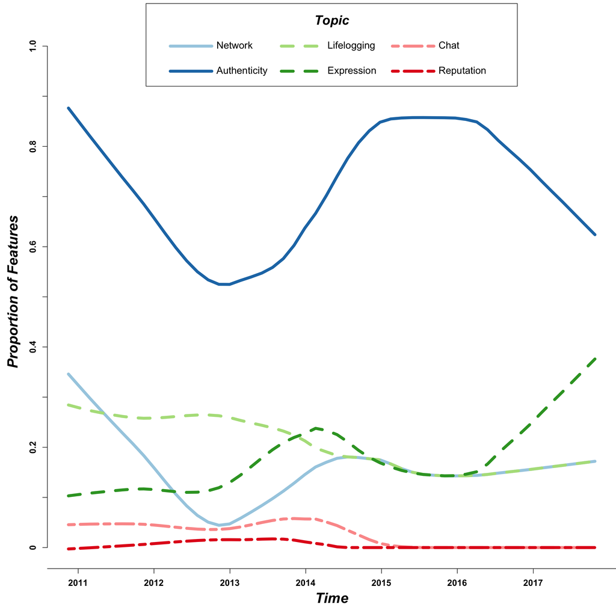

The second graph depicts the trends of the Spontaneity, Aesthetics, Privacy, Simplicity, Cost, and Integration topics.

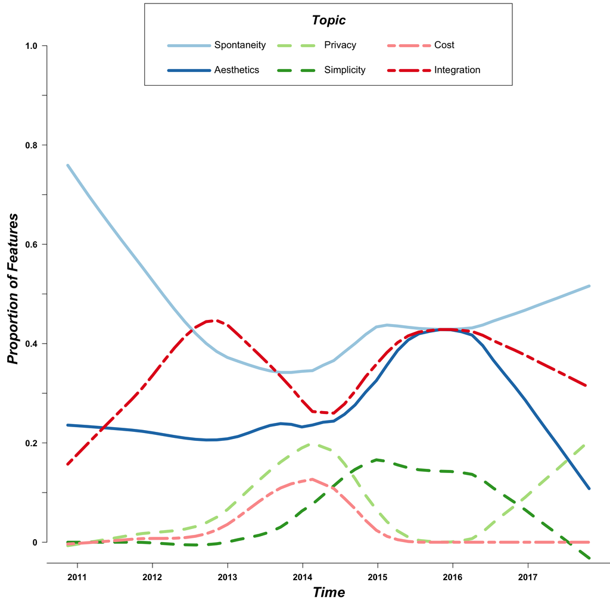

If you are interested in producing the same figures as presented in the paper, you can use the code below. Similar figures for the raw counts could be created by removing `_prop` from the variable names and adjusting the y-axis scale.

```r
years<-seq(47, 2536, by=365)
years[3:7]<-years[3:7]+1
years[7]<-years[7]+1
yearNs<-c("2011", "2012", "2013", "2014", "2015", "2016", "2017")

bettercolors <- c(
  rgb(166, 206, 227, maxColorValue=255), #light blue
  rgb(31, 120, 180, maxColorValue=255), #dark blue
  rgb(178, 223, 138, maxColorValue=255), #light green
  rgb(51, 160, 44, maxColorValue=255), #dark green
  rgb(251, 154, 153, maxColorValue=255), #light red
  rgb(227, 26, 28, maxColorValue=255)) #dark red

linetypes <- c(1, 1, 2, 2, 6, 6)

pdf("WordMatch_Prop_A.pdf", width=13, height=13)
par(mar=c(5, 5, 0, 0))
plot(1, 1, type='n', xlim=c(0, 2536), ylim=c(0, 1.05), main='', xlab='', ylab='', axes=F)
axis(1, at=c(-9999, years, 9999), labels=c(-9999, yearNs, 9999), font.axis=2, cex.axis=1.125)
text(mean(c(0, 2536)), -0.1, "Time", font=4, cex=1.8, xpd=T)
axis(2, at=seq(0, 1, by=.1), labels=c(0, "", 0.2, "", 0.4, "", 0.6, "", 0.8, "", "1.0"), font.axis=2, cex.axis=1.125)
text(-263.1797, mean(c(0, 1.02)), "Proportion of Features", font=4, cex=1.8, xpd=T, srt=90)
lines(loess.smooth(wayback$Date_num, wayback$nFeat_1_prop, span = 0.4, family = "gaussian"), col=bettercolors[1], lwd=6, lty=linetypes[1])
lines(loess.smooth(wayback$Date_num, wayback$nFeat_4_prop, span = 0.4, family = "gaussian"), col=bettercolors[2], lwd=6, lty=linetypes[2])
lines(loess.smooth(wayback$Date_num, wayback$nFeat_5_prop, span = 0.4, family = "gaussian"), col=bettercolors[3], lwd=6, lty=linetypes[3])
lines(loess.smooth(wayback$Date_num, wayback$nFeat_6_prop, span = 0.4, family = "gaussian"), col=bettercolors[4], lwd=6, lty=linetypes[4])
lines(loess.smooth(wayback$Date_num, wayback$nFeat_10_prop, span = 0.4, family = "gaussian"), col=bettercolors[5], lwd=6, lty=linetypes[5])
lines(loess.smooth(wayback$Date_num, wayback$nFeat_12_prop, span = 0.4, family = "gaussian"), col=bettercolors[6], lwd=6, lty=linetypes[6])
rect(373.7152, 0.92, 2162.285, 1.085)
text(mean(c(0, 2536)), 1.05, "Topic", font=4, cex=1.65)
segments(seq(-69.47945, 2605.479, length.out=6)[2]+25, 1.00, seq(-69.47945, 2605.479, length.out=6)[2]+225, 1.00, col=bettercolors[1], lwd=6, lty=linetypes[1])
segments(seq(-69.47945, 2605.479, length.out=6)[2]+25, 0.95, seq(-69.47945, 2605.479, length.out=6)[2]+225, 0.95, col=bettercolors[2], lwd=6, lty=linetypes[2])
segments(seq(-69.47945, 2605.479, length.out=6)[3]+25, 1.00, seq(-69.47945, 2605.479, length.out=6)[3]+225, 1.00, col=bettercolors[3], lwd=6, lty=linetypes[3])
segments(seq(-69.47945, 2605.479, length.out=6)[3]+25, 0.95, seq(-69.47945, 2605.479, length.out=6)[3]+225, 0.95, col=bettercolors[4], lwd=6, lty=linetypes[4])
segments(seq(-69.47945, 2605.479, length.out=6)[4]+25, 1.00, seq(-69.47945, 2605.479, length.out=6)[4]+225, 1.00, col=bettercolors[5], lwd=6, lty=linetypes[5])
segments(seq(-69.47945, 2605.479, length.out=6)[4]+25, 0.95, seq(-69.47945, 2605.479, length.out=6)[4]+225, 0.95, col=bettercolors[6], lwd=6, lty=linetypes[6])
text(seq(-69.47945, 2605.479, length.out=6)[2]+225, 1.00, cats[1, 2], font=1, cex=1.25, pos=4)
text(seq(-69.47945, 2605.479, length.out=6)[2]+225, 0.95, cats[4, 2], font=1, cex=1.25, pos=4)
text(seq(-69.47945, 2605.479, length.out=6)[3]+225, 1.00, cats[5, 2], font=1, cex=1.25, pos=4)
text(seq(-69.47945, 2605.479, length.out=6)[3]+225, 0.95, cats[6, 2], font=1, cex=1.25, pos=4)
text(seq(-69.47945, 2605.479, length.out=6)[4]+225, 1.00, cats[10, 2], font=1, cex=1.25, pos=4)
text(seq(-69.47945, 2605.479, length.out=6)[4]+225, 0.95, cats[12, 2], font=1, cex=1.25, pos=4)
dev.off()

pdf("WordMatch_Prop_B.pdf", width=13, height=13)
par(mar=c(5, 5, 0, 0))
plot(1, 1, type='n', xlim=c(0, 2536), ylim=c(0, 1.05), main='', xlab='', ylab='', axes=F)
axis(1, at=c(-9999, years, 9999), labels=c(-9999, yearNs, 9999), font.axis=2, cex.axis=1.125)
text(mean(c(0, 2536)), -0.1, "Time", font=4, cex=1.8, xpd=T)
axis(2, at=seq(0, 1, by=.1), labels=c(0, "", 0.2, "", 0.4, "", 0.6, "", 0.8, "", "1.0"), font.axis=2, cex.axis=1.125, las=1)
text(-263.1797, mean(c(0, 1.02)), "Proportion of Features", font=4, cex=1.8, xpd=T, srt=90)
lines(loess.smooth(wayback$Date_num, wayback$nFeat_3_prop, span = 0.4, family = "gaussian"), col=bettercolors[1], lwd=6, lty=linetypes[1])
lines(loess.smooth(wayback$Date_num, wayback$nFeat_2_prop, span = 0.4, family = "gaussian"), col=bettercolors[2], lwd=6, lty=linetypes[2])
lines(loess.smooth(wayback$Date_num, wayback$nFeat_7_prop, span = 0.4, family = "gaussian"), col=bettercolors[3], lwd=6, lty=linetypes[3])
lines(loess.smooth(wayback$Date_num, wayback$nFeat_8_prop, span = 0.4, family = "gaussian"), col=bettercolors[4], lwd=6, lty=linetypes[4])
lines(loess.smooth(wayback$Date_num, wayback$nFeat_9_prop, span = 0.4, family = "gaussian"), col=bettercolors[5], lwd=6, lty=linetypes[5])
lines(loess.smooth(wayback$Date_num, wayback$nFeat_11_prop, span = 0.4, family = "gaussian"), col=bettercolors[6], lwd=6, lty=linetypes[6])
rect(373.7152, 0.92, 2162.285, 1.085)
text(mean(c(0, 2536)), 1.05, "Topic", font=4, cex=1.65)
segments(seq(-69.47945, 2605.479, length.out=6)[2]+25, 1.00, seq(-69.47945, 2605.479, length.out=6)[2]+225, 1.00, col=bettercolors[1], lwd=6, lty=linetypes[1])
segments(seq(-69.47945, 2605.479, length.out=6)[2]+25, 0.95, seq(-69.47945, 2605.479, length.out=6)[2]+225, 0.95, col=bettercolors[2], lwd=6, lty=linetypes[2])
segments(seq(-69.47945, 2605.479, length.out=6)[3]+25, 1.00, seq(-69.47945, 2605.479, length.out=6)[3]+225, 1.00, col=bettercolors[3], lwd=6, lty=linetypes[3])
segments(seq(-69.47945, 2605.479, length.out=6)[3]+25, 0.95, seq(-69.47945, 2605.479, length.out=6)[3]+225, 0.95, col=bettercolors[4], lwd=6, lty=linetypes[4])
segments(seq(-69.47945, 2605.479, length.out=6)[4]+25, 1.00, seq(-69.47945, 2605.479, length.out=6)[4]+225, 1.00, col=bettercolors[5], lwd=6, lty=linetypes[5])
segments(seq(-69.47945, 2605.479, length.out=6)[4]+25, 0.95, seq(-69.47945, 2605.479, length.out=6)[4]+225, 0.95, col=bettercolors[6], lwd=6, lty=linetypes[6])
text(seq(-69.47945, 2605.479, length.out=6)[2]+225, 1.00, cats[3, 2], font=1, cex=1.25, pos=4)
text(seq(-69.47945, 2605.479, length.out=6)[2]+225, 0.95, cats[2, 2], font=1, cex=1.25, pos=4)
text(seq(-69.47945, 2605.479, length.out=6)[3]+225, 1.00, cats[7, 2], font=1, cex=1.25, pos=4)
text(seq(-69.47945, 2605.479, length.out=6)[3]+225, 0.95, cats[8, 2], font=1, cex=1.25, pos=4)
text(seq(-69.47945, 2605.479, length.out=6)[4]+225, 1.00, cats[9, 2], font=1, cex=1.25, pos=4)
text(seq(-69.47945, 2605.479, length.out=6)[4]+225, 0.95, cats[11, 2], font=1, cex=1.25, pos=4)
dev.off()
```

# Study 2

### Network analysis

Once we have the STM results, we can show relationships between topics using some basic network analyses. To start, we’ll load in the required packages for this section:

```r
library(igraph)
library(colorspace)
library(showtext)
```

In the plotting code below, we used the helvetica font to draw some of the text. This is not a necessary step, but it can make the base plotting used for networks look a bit better. The code below should work for most Macintosh systems; your mileage may vary on other operating systems.

```r
setwd("/System/Library/Fonts/")
font_add("helvet", regular = "Helvetica.ttc")
```

Next, let’s load in the STM results that we saved earlier, and we’ll extract just the theta matrix – or the document by topic matrix filled with fit values.

```r
stmresults<-readRDS("stm.rds")
stmresults<-stmresults$theta
```

To find relationships between STM topics, we’ll use the correlation function from base `R`. Effectively, this will show how topics tend to fit higher to a certain group of documents in the Twitter data.

```r
cormat<-cor(stmresults)
diag(cormat)<-NA
```

Next, we decided to collapse STM topics into the thirteen researcher-identified categories. To accomplish this, we’ll simply add the columns which correspond to the categories. Those topic numbers are identified in the comments.

```r
stmresults2<-matrix(nrow=dim(stmresults)[1], ncol=13)

#aesthetics <- 39, 48
#cost <- 30
#expression <- 2
#integration <- 3, 63, 73
#lifelogging <- 18
#network <- 13, 44, 56
#privacy <- 42, 72
#simplicity <- 46

stmresults2[,1]<-stmresults[,39]+stmresults[,48]
stmresults2[,2]<-stmresults[,30]
stmresults2[,3]<-stmresults[,2]
stmresults2[,4]<-stmresults[,3]+stmresults[,63]+stmresults[,73]
stmresults2[,5]<-stmresults[,18]
stmresults2[,6]<-stmresults[,13]+stmresults[,44]+stmresults[,56]
stmresults2[,7]<-stmresults[,42]+stmresults[,72]
stmresults2[,8]<-stmresults[,46]

#bugs <- 6, 8, 9, 14, 17, 20, 22, 41, 55, 65
#downfall <- 7, 25, 38, 51, 54, 59, 71, 74
#rise <- 1, 12, 15, 21, 23, 24, 26, 28, 31, 33, 35, 45, 49, 58, 64, 67, 70, 75
#uncertainty <- 4, 52, 53
#noise <- 5, 10, 11, 16, 19, 27, 29, 32, 34, 36, 37, 40, 43, 47, 50, 57, 60, 61, 62, 66, 68, 69

stmresults2[,9]<-stmresults[,6]+stmresults[,8]+stmresults[,9]+stmresults[,14]+stmresults[,17]+stmresults[,20]+stmresults[,22]+stmresults[,41]+stmresults[,55]+stmresults[,65]
stmresults2[,10]<-stmresults[,7]+stmresults[,25]+stmresults[,38]+stmresults[,51]+stmresults[,54]+stmresults[,59]+stmresults[,71]+stmresults[,74]
stmresults2[,11]<-stmresults[,1]+stmresults[,12]+stmresults[,15]+stmresults[,21]+stmresults[,23]+stmresults[,24]+stmresults[,26]+stmresults[,28]+stmresults[,31]+stmresults[,33]+stmresults[,35]+stmresults[,45]+stmresults[,49]+stmresults[,58]+stmresults[,64]+stmresults[,67]+stmresults[,70]+stmresults[,75]
stmresults2[,12]<-stmresults[,4]+stmresults[,52]+stmresults[,53]
stmresults2[,13]<-stmresults[,5]+stmresults[,10]+stmresults[,11]+stmresults[,16]+stmresults[,19]+stmresults[,27]+stmresults[,29]+stmresults[,32]+stmresults[,34]+stmresults[,36]+stmresults[,37]+stmresults[,40]+stmresults[,43]+stmresults[,47]+stmresults[,50]+stmresults[,57]+stmresults[,60]+stmresults[,61]+stmresults[,62]+stmresults[,66]+stmresults[,68]+stmresults[,69]
```

Then, just like before, we can find the relationships between topic categories by taking the correlation of the matrix.

```r
cormat2<-cor(stmresults2)
diag(cormat2)<-NA
```

Then to make the relationships work as weights in a network, we took the absolute value of the correlation matrices, rounder the results to 6 digits, and then multiplied the results by 1,000,000 so that all of the values are integers.

```r
cormat_p<-round(abs(cormat), 6)*1000000
cormat2_p<-round(abs(cormat2), 6)*1000000
```

Now that the STM results are cleaned up, we can transform these matrices into `igraph` network objects using the `graph_from_adjacency_matrix` function.

```r
net1<-graph_from_adjacency_matrix(cormat_p, mode="undirected", weighted=T, diag=F)
net2<-graph_from_adjacency_matrix(cormat2_p, mode="undirected", weighted=T, diag=F)
```

We’ll also need some vertex labels to identify topic categories:

```r
V(net2)$name<-c("Aesthetics", "Cost", "Expression", "Integration", "Lifelogging", "Network", "Privacy", "Simplicity", "Complaints", "Downfall", "Rise", "Uncertainty", "Noise")
```

From here on out, we’ll use the aggregated network, as that’s what was reported in the paper. However, you could easily apply any of the analysis or graphing functions on the full topic-to-topic network.

First, let’s look at the weighted edge values; to report the correlation rather than the transformed weights, we’ll go back to the aggregated correlation matrix:

```r
#Maximum - rise & complaints
max(abs(cormat2), na.rm=T)
```

```
## [1] 0.4026363
```

```r
#Minimum - cost & network
min(abs(cormat2), na.rm=T)
```

```
## [1] 0.001202756
```

In the paper, we then examined the eigenvector centrality scores of each topic category. This is simply calculated using the `eigen_centrality` function from `igraph`.

```r
eigen_centrality(net2)$vector
```

Here are the results:

| Category | Eigenvector Centrality |
| --- | --- |
| Rise | 1 |
| Complaints | 0.971001438605204 |
| Integration | 0.858138685083366 |
| Noise | 0.840570549865824 |
| Downfall | 0.772115024156617 |
| Uncertainty | 0.675869143682172 |
| Aesthetics | 0.674273578339512 |
| Privacy | 0.550893015653835 |
| Network | 0.487314442048549 |
| Lifelogging | 0.338440740994626 |
| Expression | 0.330839138975102 |
| Simplicity | 0.265308436436015 |
| Cost | 0.232167580529719 |

Now let’s turn to plotting the network. For the first network graph used in the paper, we used a color scheme that differentiates the topic categories by whether they are theoretical, inductively identified, or noise. Within each of those broader categories, when then differentiate topic categories by shade. To accomplish this, we’ll use the `colorRampPalette` function from the `grDevices` package.

```r
collist<-rep(NA, 13)
v.pal<-colorRampPalette(c(rgb(40/255, 0, 128/255), rgb(227/255, 214/255, 255/255)))
collist[1:8]<-v.pal(8)
v.pal<-colorRampPalette(c(rgb(0, 82/255, 22/255), rgb(179/255, 245/255, 196/255)))
collist[9:12]<-v.pal(4)
collist[13]<-"orange3"
```

Next, let’s assign the color list to a vertex attribute in the network object called `"col"`. That way, we can simply call on that network object in the plotting function and the colors will be indexed appropriately.

```r
V(net2)$col<-collist[1:13]
```

We then wanted to create a color scheme for the edges which reflects the strength of the correlation between topic categories. We can do this one of two ways:

1. We could continue to use the absolute value of the correlation matrix to who all relationships as positive (used in the paper)
2. We could show the negative correlations as a different color (red)

The code below creates edge colors ramped between transparent and black using the absolute values. Uncomment the last three lines to add in the red color for negative correlations.

```r
col1<-rgb(1, 1, 1, 0)
col2<-"black"
col3<-"darkred"
ep.pal<-colorRampPalette(c(col1, col2), alpha=T)
ep.col<-ep.pal(max(E(net2)$weight))
en.pal<-colorRampPalette(c(col1, col3), alpha=T)
en.col<-en.pal(max(E(net2)$weight))

E(net2)$col<-ep.col[c(E(net2)$weight)]
#E(net2)$pos<-0
#E(net2)$pos[cormat2[lower.tri(cormat2, diag = FALSE)]>0]<-1
#E(net2)$col[E(net2)$pos==0]<-en.col[c(E(net2)$weight[E(net2)$pos==0])]
```

Next, we need a layout for the nodes. Since we used a correlation matrix to create the network, its fully connected. A layout created from a sparsely-connected network is more informative, so we first removed all of the edges below the median weight. Then, we can use the `layout_with_fr` function to generate the Fruchterman-Reingold layout. Because this is a non-deterministic process, we set a seed first.

```r
net2b<-delete_edges(net2, E(net2)[E(net2)$weight<=quantile(E(net2)$weight, probs=.5)])
set.seed(748219)
layout2.2<-layout_with_fr(net2b, niter=10000)
layout2.2<-norm_coords(layout2.2)
```

Great, now that we have all of the components, let’s plot the network:

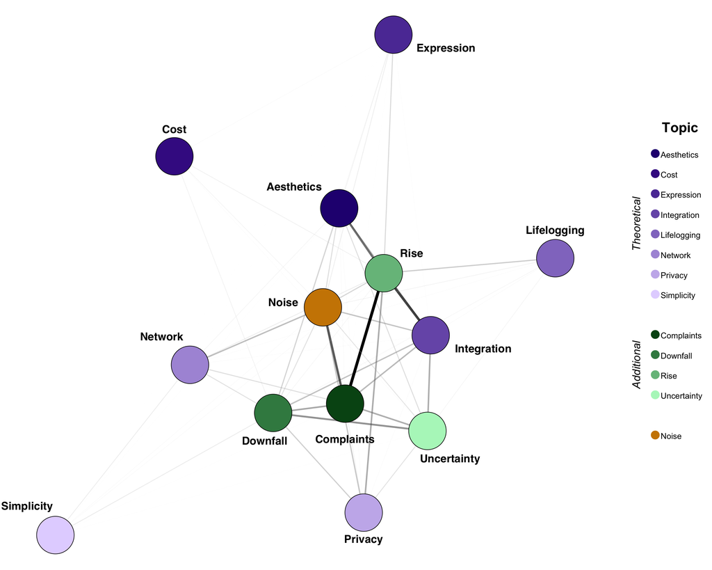

Finally, the last network analysis we conducted was community detection, specifically using the spinglass method. Because this is non-deterministic, we again set a seed. Then, using the community membership information, we can add a new vertex attribute which we’ll use to plot the color of the communities.

```r
set.seed(246810)
cl<-cluster_spinglass(net2)
V(net2)$fcol<-NA
V(net2)$fcol[cl$membership==1]<-"red3"
V(net2)$fcol[cl$membership==2]<-"springgreen2"
V(net2)$fcol[cl$membership==3]<-"deepskyblue4"
```

And here’s what that looks like plotted:

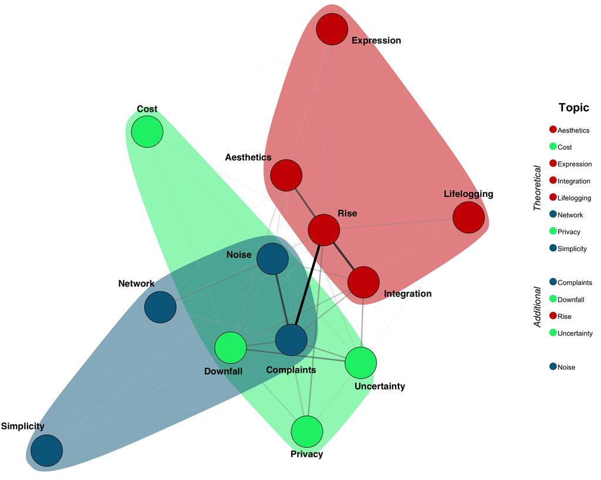

If you want to be able to recreate these graphs for yourself, you can use the following code:

```r
pdf("AggNet_1.pdf", 10, 8)
showtext_begin()
par(mar=c(0, 2, 0, 11.25))
plot(net2, edge.color=E(net2)$col, edge.width=(E(net2)$weight/80000), vertex.color=V(net2)$col, vertex.size=15, vertex.label.font=2, vertex.label.cex=1.2, vertex.label.color="black", vertex.label.degree=c((pi*8)/7, (pi*3)/2, pi/12, pi/12, (pi*3)/2, (pi*5)/4, pi/2, (pi*5)/4, pi/2, (pi*19)/32, (pi*9)/5, (pi*2)/7, (pi*25)/24), vertex.label.dist=c(2.75, 1.5, 3, 3, 1.5, 2.2, 1.5, 2.2, 2, 1.6, 1.9, 2, 2.2), vertex.label.family='helvet', layout=layout2.2, rescale=F, xlim=c(-1.05, 1.05), ylim=c(-1.05, 1.05))
rect(1.25, -0.7, 1.75, 0.7, lwd=2)
text(mean(c(1.25, 1.75)), 0.625, "Topic", font=2, cex=1.5)
points(rep(1.4, 13), seq(0.525, -0.6, length.out=15)[c(1:8, 10:13, 15)], col=collist[1:13], pch=19, cex=2)
text(rep(1.4, 13), seq(0.525, -0.6, length.out=15)[c(1:8, 10:13, 15)]-.0075, c("Aesthetics", "Cost", "Expression", "Integration", "Lifelogging", "Network", "Privacy", "Simplicity", "Complaints", "Downfall", "Rise", "Uncertainty", "Noise"), pos=4, cex=0.9)
text(1.325, mean(seq(0.525, -0.6, length.out=15)[c(1, 8)]), "Theoretical", font=3, cex=1.2, srt=90)
text(1.325, mean(seq(0.525, -0.6, length.out=15)[c(10, 13)]), "Additional", font=3, cex=1.2, srt=90)
text(-1.175, 1.125, "A", font=2, cex=3, xpd=T)
showtext_end()
dev.off()

pdf("AggNet_2.pdf", 10, 8)
showtext_begin()
par(mar=c(0, 2, 0, 11.25))
plot(cl, net2, col=V(net2)$fcol, mark.border=NA, mark.col=c(adjustcolor("red3", alpha.f=0.5), adjustcolor("springgreen2", alpha.f=0.5), adjustcolor("deepskyblue4", alpha.f=0.5)), edge.color=E(net2)$col, edge.width=(E(net2)$weight/80000), vertex.size=15, vertex.label.font=2, vertex.label.cex=1.2, vertex.label.color="black", vertex.label.degree=c((pi*8)/7, (pi*3)/2, pi/12, pi/12, (pi*3)/2, (pi*5)/4, pi/2, (pi*5)/4, pi/2, (pi*19)/32, (pi*9)/5, (pi*2)/7, (pi*25)/24), vertex.label.dist=c(2.75, 1.5, 3, 3, 1.5, 2.2, 1.5, 2.2, 2, 1.6, 1.9, 2, 2.2), vertex.label.family='helvet', layout=layout2.2, rescale=F, xlim=c(-1.05, 1.05), ylim=c(-1.05, 1.05))
rect(1.25, -0.7, 1.75, 0.7, lwd=2)
text(mean(c(1.25, 1.75)), 0.625, "Topic", font=2, cex=1.5)
points(rep(1.4, 13), seq(0.525, -0.6, length.out=15)[c(1:8, 10:13, 15)], col=V(net2)$fcol, pch=19, cex=2)
text(rep(1.4, 13), seq(0.525, -0.6, length.out=15)[c(1:8, 10:13, 15)]-.0075, c("Aesthetics", "Cost", "Expression", "Integration", "Lifelogging", "Network", "Privacy", "Simplicity", "Complaints", "Downfall", "Rise", "Uncertainty", "Noise"), pos=4, cex=0.9)
text(1.325, mean(seq(0.525, -0.6, length.out=15)[c(1, 8)]), "Theoretical", font=3, cex=1.2, srt=90)
text(1.325, mean(seq(0.525, -0.6, length.out=15)[c(10, 13)]), "Additional", font=3, cex=1.2, srt=90)
text(-1.175, 1.125, "B", font=2, cex=3, xpd=T)
showtext_end()
dev.off()
```

### Web scraping the WayBack archive

To compare the Twitter results against the full set of Path’s App Store features, we’ll need to first scrape the Wayback machine for all of Path’s App Store webpages. There are a number of packages which will allow us to put this data set together:

```r
library(rjson)
library(rvest)
library(stringr)
library(ngram)
library(parallel)
```

Note: the parallel package is not necessary, but it helps speed up the process. The parallel code presented here will work on Mac and Linux machines. On Windows, make sure to comment out all instances of parallel code (e.g., “mc.cores=detectCores()”).

We want to create a query for each day between November 15, 2010 (when Path goes live on the App Store) and December 31, 2017 (the end of our Twitter collection). We’ll start by listing out each day in R’s Date format:

```r
dates<-as.character(as.Date(as.Date("2010-11-15"):as.Date("2017-12-31"), origin="1970-01-01"))
dates2<-gsub("-", "", dates)
```

Next, I wrote a function that takes each day in the list we created, appends the character string to the URL used by the WayBack archive for Path’s App Store page, and performs a JSON query using WayBack’s API and the `rjson` package. The WayBack API returns an object called “closest URL” – this tells us the most recent snapshot relative to the date provided by the query. By returning the unique results, we can get a URL list of all of the unique snapshots contained in the WayBack archive.

```r
jsonfn<-function(i){
  file<-fromJSON(file=paste("https://archive.org/wayback/available?url=http://itunes.apple.com/us/app/path/id403639508?mt=8&timestamp=", dates2[i], sep=""))
  return(file$archived_snapshots$closest$url)
}
waybacks<-unlist(lapply(1:length(dates2), jsonfn))
waybacks<-unique(waybacks)
```

Here’s an example of the output provided:

```
## [1] "http://web.archive.org/web/20101115230956/http://itunes.apple.com/us/app/path/id403639508?mt=8"
## [2] "http://web.archive.org/web/20101117042833/http://itunes.apple.com/us/app/path/id403639508?mt=8"
## [3] "http://web.archive.org/web/20101118023115/http://itunes.apple.com:80/us/app/path/id403639508?mt=8"
## [4] "http://web.archive.org/web/20101118044211/http://itunes.apple.com:80/us/app/path/id403639508?mt=8"
## [5] "http://web.archive.org/web/20101123031002/http://itunes.apple.com/us/app/path/id403639508?mt=8"
```

Next, the date and time of the snapshots are embedded in the URL. These functions pull them out using substring functions from the `stringr` package:

```r
datefn<-function(i){
  year<-str_sub(waybacks[i], 28, 31)
  month<-str_sub(waybacks[i], 32, 33)
  day<-str_sub(waybacks[i], 34, 35)
  date<-paste(year, "-", month, "-", day, sep="")
  return(date)
}

dates<-unlist(mclapply(1:length(waybacks), datefn, mc.cores=detectCores()-1))

timefn<-function(i){
  hours<-str_sub(waybacks[i], 36, 37)
  minutes<-str_sub(waybacks[i], 38, 39)
  seconds<-str_sub(waybacks[i], 40, 41)
  time<-paste(hours, ":", minutes, ":", seconds, sep="")
  return(time)
}

times<-unlist(mclapply(1:length(waybacks), timefn, mc.cores=detectCores()-1))
```

Now, put these together in a data frame called `wayback`:

```r
wayback<-as.data.frame(cbind(dates, times, waybacks))
names(wayback)<-c("Date", "Time", "URL")
wayback$URL<-as.character(wayback$URL)
```

Now that we have the URL for each snapshot, we need to pull the description text. This function uses the `rvest` package to:

- read in the html file
- drill down to the node called “.product-review”, where the description is stored
- convert that to an `R` character string
  - if the result is more than one character string, paste them together

```r
descfn<-function(i){
  webpage<-read_html(wayback$URL[i])
  prodrev<-html_nodes(webpage,'.product-review')
  outs<-html_text(prodrev)
  if(length(outs)>1){
    temp<-outs[1]
    for(j in 2:length(outs)){
      temp<-paste(temp, outs[j])
    }
    outs<-temp
  }
  return(outs)
}

wayback$Description<-lapply(1:dim(wayback)[1], descfn)
```

Here’s an example of the result:

```
## [[1]]
## [1] "\n  \n    \n      \n      Description\n    \n    \n  \n  \n    Path is the personal social network that is the best way to share life and stay connected with family and friends. By focusing on beautiful design and experience, Path is 5-star rated and loved by millions of people.Be closer to …
```

Now that we have the description texts, we next need to begin parsing the paragraphs for the important parts. In the example above, notice how the feature list appears before the version number. This will be an important split point and we can extract the version number in the process. The code below starts by adding the version 1.0 to all observations for which the description does not contain the phrase “What’s New in Version”. For other observations, we’ll split the text using this phrase. The first half will be retained and we can extract the version number from the second half using a substring function. Once this step is completed, we’ll get rid of d1 and d2 – the split halves – as they’re no longer needed.

```r
wayback$Version<-NA
wayback$Version[!grepl("What's New in Version", wayback$Description)]<-"1.0"
wayback$d1<-NA
wayback$d2<-NA

splitFn1<-function(i){
  if(!grepl("What's New in Version", wayback$Description[i])){
    return(wayback$Description[i])
  }
  if(grepl("What's New in Version", wayback$Description[i])){
    return(unlist(str_split(unlist(wayback$Description[i]), "What's New in Version"))[1])
  }
}

splitFn2<-function(i){
  if(!grepl("What's New in Version", wayback$Description[i])){
    return(NA)
  }
  if(grepl("What's New in Version", wayback$Description[i])){
    return(unlist(str_split(unlist(wayback$Description[i]), "What's New in Version"))[2])
  }
}

wayback$d1<-unlist(mclapply(1:dim(wayback)[1], splitFn1, mc.cores=detectCores()-1))
wayback$d2<-unlist(mclapply(1:dim(wayback)[1], splitFn2, mc.cores=detectCores()-1))

wayback$Version[grepl("What's New in Version", wayback$Description)]<-substr(wayback$d2, 0, 8)[grepl("What's New in Version", wayback$Description)]

wayback$Version<-gsub("\n", " ", wayback$Version)
wayback$Version<-str_trim(wayback$Version)

wayback$Description<-wayback$d1
wayback<-wayback[1:5]
```

The next step involves cleaning up a lot of the extraneous text formatting. Using the `gsub` command from base `R`, we’ll replace the “Description” heading and linebreaks with spaces. Then we’ll remove extra spaces from the ends and between each word using the `str_trim` and `str_squish` functions (respectively) found in the `stringr` package.

```r
wayback$Description<-gsub("Description\n", " ", wayback$Description)
wayback$Description<-gsub("\n", " ", wayback$Description)
wayback$Description<-str_trim(wayback$Description)
wayback$Description<-str_squish(wayback$Description)
```

Now that the texts are prepared, the next step will be to extract the individual features from their lists. Unfortunately, Path was not consistent in the way they formatted their features lists over the ~7 years we collected. So in order to split the text, we’ll need to code a rule for each observation which captures the format that was used. The solution provided below is inelegant, but it works for our data set. Your mileage will, of course, vary.

```r
wayback$SplitRule<-NA
#Split on "•"
  wayback$SplitRule[grepl("•", wayback$Description)]<-1
#Split on "★"
  wayback$SplitRule[grepl("★", wayback$Description) & !grepl("★ ★", wayback$Description)]<-2
#Split on "☆"
  wayback$SplitRule[grepl("☆", wayback$Description)]<-3
#Split first on "Features:", then on "- "
  wayback$SplitRule[grepl("Features:", wayback$Description) & is.na(wayback$SplitRule)]<-"4a"
#Just split on "- "
  wayback$SplitRule[is.na(wayback$SplitRule)][grepl("On Path, you can:", wayback$Description[is.na(wayback$SplitRule)])]<-"4b"
#Split on "[.]"
  wayback$SplitRule[is.na(wayback$SplitRule)][grepl(".*:", wayback$Description[is.na(wayback$SplitRule)])]<-"5a"
#Split on "[.]", with "Features" at the start
  wayback$SplitRule[wayback$SplitRule=="5a" & grepl("Features", wayback$Description)]<-"5b"
```

Next, let’s make some empty feature variables to fill. Through some experimentation (starting with many more than 14 and trimming back the code later), I found that the maximum number of features contained in a single observation is 14.

```r
wayback$Feature_1<-NA
wayback$Feature_2<-NA
wayback$Feature_3<-NA
wayback$Feature_4<-NA
wayback$Feature_5<-NA
wayback$Feature_6<-NA
wayback$Feature_7<-NA
wayback$Feature_8<-NA
wayback$Feature_9<-NA
wayback$Feature_10<-NA
wayback$Feature_11<-NA
wayback$Feature_12<-NA
wayback$Feature_13<-NA
wayback$Feature_14<-NA
```

Great! Now comes the hard part: splitting the character string according to each of the seven rules described above. First, we’ll cycle through each observation using a for loop. Then, we’ll determine which of the seven rules to apply. If the rule states that “Feature” precedes the list, we’ll first split on that word. Then, we’ll split on the character string shown above, trimming extra spaces from the ends as we do so. The result of this split is a vector, so we can iterate through the length of the list and use that index (`j`) to determing which variable in the data frame to write to. Some additional formatting is applied depending on the rule. The only exception to this general format is rule 4a – there were some cases where a hyphen, the character used for splitting, interupts the same feature. Luckily, when this occurs, the splitting results in the two parts of the feature containing fewer than 5 words – and all other features contain greater than 5 words. We used the `wordcount` function available in the `ngram` package to determine when this was the case, and to paste the two halves back together as they were intended. This is another inelegant solution, but one that works for the data we have.

```r
for(i in 1:dim(wayback)[1]){
  #Rule 1
  if(!is.na(wayback$SplitRule[i]) & wayback$SplitRule[i]==1){
    templist<-trimws(unlist(str_split(wayback$Description[i], "•")))
    templist<-templist[2:length(templist)]
    for(j in 1:length(templist)){
      wayback[[paste("Feature_", j, sep="")]][i]<-templist[j]
    }
    rm(templist)
  }
  #Rule 2
  if(!is.na(wayback$SplitRule[i]) & wayback$SplitRule[i]==2){
    templist<-trimws(unlist(str_split(wayback$Description[i], "★")))
    templist<-templist[2:length(templist)]
    for(j in 1:length(templist)){
      wayback[[paste("Feature_", j, sep="")]][i]<-templist[j]
    }
    rm(templist)
  }
  #Rule 3
  if(!is.na(wayback$SplitRule[i]) & wayback$SplitRule[i]==3){
    templist<-trimws(unlist(str_split(wayback$Description[i], "☆")))
    templist<-templist[2:length(templist)]
    for(j in 1:length(templist)){
      wayback[[paste("Feature_", j, sep="")]][i]<-templist[j]
    }
    rm(templist)
  }
  #Rule 4a
  if(!is.na(wayback$SplitRule[i]) & wayback$SplitRule[i]=="4a"){
    temptxt<-unlist(str_split(wayback$Description[i], "Features:"))[2]
    templist<-trimws(unlist(str_split(temptxt, "- ")))
    templist<-templist[templist!=""]
    wordcounts<-rep(NA, length(templist))
    for(j in 1:length(wordcounts)){
      wordcounts[j]<-wordcount(templist[j])
    }
    for(j in 1:length(templist)){
      if(wordcounts[j]<=5){
        templist[j+1]<-paste(templist[j], templist[j+1], sep=" - ")
      }
    }
    templist<-templist[wordcounts>5]
    for(j in 1:length(templist)){
      wayback[[paste("Feature_", j, sep="")]][i]<-templist[j]
    }
    rm(temptxt)
    rm(templist)
  }
  #Rule 4b
  if(!is.na(wayback$SplitRule[i]) & wayback$SplitRule[i]=="4b"){
    templist<-trimws(unlist(str_split(wayback$Description[i], "- ")))
    templist<-templist[2:length(templist)]
    for(j in 1:length(templist)){
      wayback[[paste("Feature_", j, sep="")]][i]<-templist[j]
    }
    rm(templist)
  }
  #Rule 5a
  if(!is.na(wayback$SplitRule[i]) & wayback$SplitRule[i]=="5a"){
    templist<-trimws(unlist(str_split(wayback$Description[i], "[.]")))
    templist<-templist[templist!=""]
    templist<-templist[2:length(templist)]
    for(j in 1:length(templist)){
      if(!grepl(":", templist[j])){
        templist[j-1]<-paste(templist[j-1], templist[j], sep=". ")
      }
    }
    templist<-templist[grepl(":", templist)]
    for(j in 1:length(templist)){
      wayback[[paste("Feature_", j, sep="")]][i]<-templist[j]
    }
    rm(templist)
  }
  #Rule 5b
  if(!is.na(wayback$SplitRule[i]) & wayback$SplitRule[i]=="5b"){
    temptxt<-unlist(str_split(wayback$Description[i], "Features"))[2]
    templist<-trimws(unlist(str_split(temptxt, "[.]")))
    templist<-templist[templist!=""]
    for(j in 1:length(templist)){
      if(!grepl(":", templist[j])){
        templist[j-1]<-paste(templist[j-1], templist[j], sep=". ")
      }
    }
    templist<-templist[grepl(":", templist)]
    for(j in 1:length(templist)){
      wayback[[paste("Feature_", j, sep="")]][i]<-templist[j]
    }
    rm(temptxt)
    rm(templist)
  }
}
```

Once that step is complete, we need only to clean up the “features” we don’t need for our analyses and to count up the number of features in each observation. First, we’ll get rid of links to testimonials in the press. Then, we’ll remove device compatibility text. Finally, some of the last features on a list contained the sentiment “enjoy”, which is not relevant to the function of the application.

```r
wayback[!is.na(wayback) & wayback=="Path in The New York Times: http://nyti.ms/cVs14J"]<-NA
wayback[!is.na(wayback) & wayback=="Path in The Los Angeles Times: http://lat.ms/bszNxl"]<-NA
wayback[!is.na(wayback) & wayback=="Path in Wired: http://bit.ly/9mQePM"]<-NA
wayback[!is.na(wayback) & wayback=="Path in Forbes: http://bit.ly/cC2x62"]<-NA

wayback$Feature_5<-gsub("Compatible with any iPhone or iPod Touch running iOS 4.0 or above.Enjoy Path on iPhone or on the Web at www.path.com.Learn More:", "", wayback$Feature_5)
wayback$Feature_5<-gsub("Compatible with any iPhone or iPod Touch running iOS 4.0 or above.Enjoy Path on iPhone or on the Web at www.path.com.Path Elsewhere:", "", wayback$Feature_5)
wayback$Feature_5<-gsub("Compatible with any iPhone or iPod Touch running iOS 4.0 or above.Enjoy Path on iPhone or on the Web at www.path.com.Path in The New York Times: http://nyti.ms/cVs14JPath in The Los Angeles Times: http://lat.ms/bszNxlPath in Wired: http://bit.ly/9mQePMPath in Forbes: http://bit.ly/cC2x62", "", wayback$Feature_5)
wayback$Feature_5<-gsub("Compatible with any iPhone running iOS 4.0 or above.Enjoy Path on iPhone or on the Web at www.path.com.", "", wayback$Feature_5)
wayback$Feature_7<-gsub("Compatible with any iPhone or iPod Touch running iOS 4.0 or above.Enjoy Path on iPhone or on the Web at www.path.com.Learn More:", "", wayback$Feature_7)

wayback$Feature_8<-gsub(".Enjoy.", ".", wayback$Feature_8)
wayback$Feature_10<-gsub(".Enjoy.", ".", wayback$Feature_10)
```

Lastly, we need to count the number of features contained in each observation. Since the variable names in the data frame contain the ordered feature number, and data are missing from higher feature numbers after the last feature in the order, we need only add to the count iteratively:

```r
wayback$nFeatures<-0
wayback$nFeatures[!is.na(wayback$Feature_1)]<-1
wayback$nFeatures[!is.na(wayback$Feature_2)]<-2
wayback$nFeatures[!is.na(wayback$Feature_3)]<-3
wayback$nFeatures[!is.na(wayback$Feature_4)]<-4
wayback$nFeatures[!is.na(wayback$Feature_5)]<-5
wayback$nFeatures[!is.na(wayback$Feature_6)]<-6
wayback$nFeatures[!is.na(wayback$Feature_7)]<-7
wayback$nFeatures[!is.na(wayback$Feature_8)]<-8
wayback$nFeatures[!is.na(wayback$Feature_9)]<-9
wayback$nFeatures[!is.na(wayback$Feature_10)]<-10
wayback$nFeatures[!is.na(wayback$Feature_11)]<-11
wayback$nFeatures[!is.na(wayback$Feature_12)]<-12
wayback$nFeatures[!is.na(wayback$Feature_13)]<-13
wayback$nFeatures[!is.na(wayback$Feature_14)]<-14
```

Here are some summary statistics for the `nFeatures` variable we just created:

```
## [1] "Mean: 8.58579881656805"
```

```
## [1] "Standard Deviation: 4.14686192109379"
```

```
##
##  0  5  6  7  8 10 11 13 14
## 17 23  9  7 43  7  1 60  2
```

As an added cleaning step, we decided to remove eleven cases from the data set. These are observations which occur at a later time, but on the same date as another observation. This step helps simplify how we should handle the data for the vector autoregression to follow. In all cases, when two observations occur on the same day, the content is identical between them.

```r
wayback$Duplicated<-0
for(i in 2:dim(wayback)[1]){
  if(wayback$Date[i]==wayback$Date[i-1]){
    wayback$Duplicated[i]<-1
  }
}
wayback<-wayback[wayback$Duplicated==0,1:21]
```

Finally, we saved this data frame as “Wayback_Complete.rds” – the same data file should be available for download from the same repository where this markdown file is located. This file can be read back into `R` using the command `readRDS()`.

```r
saveRDS(wayback, "Wayback_Complete.rds")
```

### Vector autoregression

To relate the content of Tweets pertaining to Path to the content of Path’s App Store feature lists, we used modeling technique called “vector autoregression”, or VAR. This technique is a relatively straight-forward kind of time-series analysis in which one measure can be shown to relate to another over time. For this portion of the analysis, we’ll rely on the following packages:

```r
library(parallel)
library(vars)
library(zoo)
library(stm)
```

Once again, the `parallel` package allows us to make use of multiple processing cores on modern machines. The parallel code in this section has been verified to work on most Macintosh and Linux systems. If you are using a Windows machine, I suggest that you remove parallel code.

This section is broken down into two parts: cleaning/imputation and VAR results.

#### Cleaning and Imputation

We have two sets of data that we would like to relate to one another: Path’s Wayback Features and the Twitter STM results. We’ll start by reading them in and converting the timestamp to the appropriate `Date` format – the Date conversion is important as this is used to index the measures over time.

```r
wayback<-readRDS("Wayback_Complete.rds")
wayback$Date<-as.Date(as.character(wayback$Date))
```

```r
twitter<-readRDS("Path_Data_noHTMLorTAG.rds")
twitter$date<-as.Date(twitter$Date_EST)
```

On the Twitter side, we have a number of documents which were removed in the cleaning steps of the STM procedures. The text processor results were saved and there is a variable in that result called `docs.removed` which tells `R` the indices of our Twitter data which were removed in cleaning.

```r
textPro<-readRDS("textPro.rds")
twitter<-twitter[-(textPro$docs.removed),]
```

Next, lets read in the STM results – here, we’re specifically looking for the theta matrix, or the fitted values for each document to each topic.

```r
stmresults<-readRDS("stm.rds")
stmresults<-stmresults$theta
```

Now that we have the STM results read in, we can determine which of the 75 modeled topics each observation fits best to. The variable `Topic_fit` stores the maximum theta value, and the variable `Topic` then stores the integer (1 through 75) which corresponds to the topic which that theta belongs to for the observation. There may be more efficient means to store this information, but it runs quick enough for our purposes.

```r
twitter$Topic<-NA
twitter$Topic_fit<-NA
for(i in 1:dim(twitter)[1]){
  twitter$Topic_fit[i]<-max(stmresults[i,])
  for(j in 1:dim(stmresults)[2]){
    if(stmresults[i,j]==twitter$Topic_fit[i]){
      twitter$Topic[i]<-j
    }
  }
}
```

Now, for the VAR analyses, we will need to have the data condensed to some uniform period of time (i.e., the time gaps between observations need to be uniform). To do that, we created averages at three time points: daily, weekly, and monthly. We’ll start first with daily.

Because the Wayback data is already ordered by date with the earliest first, we can begin the construction of our `days` dataframe by iterating from the first entry (November 15, 2010; the day Path became available on the App Store) to the end of our data collection period (December 31, 2017).

```r
days<-as.data.frame(cbind(wayback$Date[1]:as.Date("2017-12-31")))
names(days)[1]<-"date"
days$date<-as.Date(days$date, origin="1970-1-1")
```

Then, to determine how many Twitter observations we have to each day, let’s create a new variable in the dataframe:

```r
days$twit_nObs<-0
for(i in 1:dim(days)[1]){
  days$twit_nObs[i]<-length(twitter$date[twitter$date==days$date[i]])
}
```

Next, we need a function that will return the proportion of tweets on a given day that were categorized into one of the eight topic categories which appear in *both* Path’s App Store Features *and* the STM results. Those topics are:

1. Aesthetics
2. Cost
3. Expression
4. Integration
5. Lifelogging
6. Network
7. Privacy
8. Simplicity

When there are no observations for a day, we’ll return `NA` for now. Finally, to make the function work across all topic categories, we’ll add a `type` parameter which tells the function which topic numbers to check for (shown in the comments). Here is the resulting function:

```r
#aesthetics <- 39, 48
#cost <- 30
#expression <- 2
#integration <- 3, 63, 73
#lifelogging <- 18
#network <- 13, 44, 56
#privacy <- 42, 72
#simplicity <- 46

twitFillFn<-function(i, type){
  if(!(days$date[i] %in% twitter$date)){
    return(NA)
  }
  if((days$date[i] %in% twitter$date) & type==1){
    return(length(twitter$Topic[(twitter$Topic==39 | twitter$Topic==48) & twitter$date==days$date[i]])/days$twit_nObs[i])
  }
  if((days$date[i] %in% twitter$date) & type==2){
    return(length(twitter$Topic[twitter$Topic==30 & twitter$date==days$date[i]])/days$twit_nObs[i])
  }
  if((days$date[i] %in% twitter$date) & type==3){
    return(length(twitter$Topic[twitter$Topic==2 & twitter$date==days$date[i]])/days$twit_nObs[i])
  }
  if((days$date[i] %in% twitter$date) & type==4){
    return(length(twitter$Topic[(twitter$Topic==3 | twitter$Topic==63 | twitter$Topic==73) & twitter$date==days$date[i]])/days$twit_nObs[i])
  }
  if((days$date[i] %in% twitter$date) & type==5){
    return(length(twitter$Topic[twitter$Topic==18 & twitter$date==days$date[i]])/days$twit_nObs[i])
  }
  if((days$date[i] %in% twitter$date) & type==6){
    return(length(twitter$Topic[(twitter$Topic==13 | twitter$Topic==44 | twitter$Topic==56) & twitter$date==days$date[i]])/days$twit_nObs[i])
  }
  if((days$date[i] %in% twitter$date) & type==7){
    return(length(twitter$Topic[(twitter$Topic==42 | twitter$Topic==72) & twitter$date==days$date[i]])/days$twit_nObs[i])
  }
  if((days$date[i] %in% twitter$date) & type==8){
    return(length(twitter$Topic[(twitter$Topic==46) & twitter$date==days$date[i]])/days$twit_nObs[i])
  }
}
```

The data can be added to the frame in parallel using the `mclapply` function from the `parallel` package. If you would like to run this code on a Windows machine, change `mclapply` to `lapply` and remove the `mc.cores` parameter from the function call.

```r
days$twit_aesthetics<-unlist(mclapply(1:dim(days)[1], twitFillFn, type=1, mc.cores=detectCores()))
days$twit_cost<-unlist(mclapply(1:dim(days)[1], twitFillFn, type=2, mc.cores=detectCores()))
days$twit_expression<-unlist(mclapply(1:dim(days)[1], twitFillFn, type=3, mc.cores=detectCores()))
days$twit_integration<-unlist(mclapply(1:dim(days)[1], twitFillFn, type=4, mc.cores=detectCores()))
days$twit_lifelogging<-unlist(mclapply(1:dim(days)[1], twitFillFn, type=5, mc.cores=detectCores()))
days$twit_network<-unlist(mclapply(1:dim(days)[1], twitFillFn, type=6, mc.cores=detectCores()))
days$twit_privacy<-unlist(mclapply(1:dim(days)[1], twitFillFn, type=7, mc.cores=detectCores()))
days$twit_simplicity<-unlist(mclapply(1:dim(days)[1], twitFillFn, type=8, mc.cores=detectCores()))
```

Next, we’ll need the Path coded results at a daily level. Although a count of the Wayback observations at the daily level is not necessary for calculating the proportions, it may come in handy when attempting to diagnose any problems with the imputation process.

```r
days$path_nObs<-0
for(i in 1:dim(days)[1]){
  days$path_nObs[i]<-length(wayback$Date[wayback$Date==days$date[i]])
}
```

Before we pull in the data to the daily level, we’ll first make sure that all of the `NA` observations are replaced with `0`. The topic categories are represented by a number indicated in the comments.

```r
#aesthetics <- 2
#cost <- 9
#expression <- 6
#integration <- 11
#lifelogging <- 5
#network <- 1
#privacy <- 7
#simplicity <- 8

wayback$pFeat_t2[is.na(wayback$pFeat_t2)]<-0
wayback$pFeat_t9[is.na(wayback$pFeat_t9)]<-0
wayback$pFeat_t6[is.na(wayback$pFeat_t6)]<-0
wayback$pFeat_t11[is.na(wayback$pFeat_t11)]<-0
wayback$pFeat_t5[is.na(wayback$pFeat_t5)]<-0
wayback$pFeat_t1[is.na(wayback$pFeat_t1)]<-0
wayback$pFeat_t7[is.na(wayback$pFeat_t7)]<-0
wayback$pFeat_t8[is.na(wayback$pFeat_t8)]<-0
```

Next, we’ll create a similar filling function for the path results:

```r
pathFillFn<-function(i, type){
  if(!(days$date[i] %in% wayback$Date)){
    return(NA)
  }
  if((days$date[i] %in% wayback$Date) & type==1){
    return(wayback$pFeat_t2[wayback$Date==days$date[i]])
  }
  if((days$date[i] %in% wayback$Date) & type==2){
    return(wayback$pFeat_t9[wayback$Date==days$date[i]])
  }
  if((days$date[i] %in% wayback$Date) & type==3){
    return(wayback$pFeat_t6[wayback$Date==days$date[i]])
  }
  if((days$date[i] %in% wayback$Date) & type==4){
    return(wayback$pFeat_t11[wayback$Date==days$date[i]])
  }
  if((days$date[i] %in% wayback$Date) & type==5){
    return(wayback$pFeat_t5[wayback$Date==days$date[i]])
  }
  if((days$date[i] %in% wayback$Date) & type==6){
    return(wayback$pFeat_t1[wayback$Date==days$date[i]])
  }
  if((days$date[i] %in% wayback$Date) & type==7){
    return(wayback$pFeat_t7[wayback$Date==days$date[i]])
  }
  if((days$date[i] %in% wayback$Date) & type==8){
    return(wayback$pFeat_t8[wayback$Date==days$date[i]])
  }
}
```

… and we can fill the data frame using the following parallel code:

```r
days$path_aesthetics<-unlist(mclapply(1:dim(days)[1], pathFillFn, type=1, mc.cores=detectCores()))
days$path_cost<-unlist(mclapply(1:dim(days)[1], pathFillFn, type=2, mc.cores=detectCores()))
days$path_expression<-unlist(mclapply(1:dim(days)[1], pathFillFn, type=3, mc.cores=detectCores()))
days$path_integration<-unlist(mclapply(1:dim(days)[1], pathFillFn, type=4, mc.cores=detectCores()))
days$path_lifelogging<-unlist(mclapply(1:dim(days)[1], pathFillFn, type=5, mc.cores=detectCores()))
days$path_network<-unlist(mclapply(1:dim(days)[1], pathFillFn, type=6, mc.cores=detectCores()))
days$path_privacy<-unlist(mclapply(1:dim(days)[1], pathFillFn, type=7, mc.cores=detectCores()))
days$path_simplicity<-unlist(mclapply(1:dim(days)[1], pathFillFn, type=8, mc.cores=detectCores()))
```

Let’s save our progress on the days data frame:

```r
saveRDS(days, "Days_w_NA.rds")
```

The last thing to do with the daily data is to impute values for the missing observations. VAR cannot handle gaps in the time series data, so we need to fill in those gaps. We’ll use two techniques: for the Twitter data, we’ll use a linear interpolation method (described in the paper). For the Path Wayback data, we’ll use a feed-forward approach which simply takes the most recent observation and imputes that value forward in time until another observation is found. These use the `na.approx` and `na.locf` functions (respectively) from the `zoo` package.

```r
days$twit_aesthetics<-na.approx(days$twit_aesthetics)
days$twit_cost<-na.approx(days$twit_cost)
days$twit_expression<-na.approx(days$twit_expression)
days$twit_integration<-na.approx(days$twit_integration)
days$twit_lifelogging<-na.approx(days$twit_lifelogging)
days$twit_network<-na.approx(days$twit_network)
days$twit_privacy<-na.approx(days$twit_privacy)
days$twit_simplicity<-na.approx(days$twit_simplicity)

days$path_aesthetics<-na.locf(days$path_aesthetics)
days$path_cost<-na.locf(days$path_cost)
days$path_expression<-na.locf(days$path_expression)
days$path_integration<-na.locf(days$path_integration)
days$path_lifelogging<-na.locf(days$path_lifelogging)
days$path_network<-na.locf(days$path_network)
days$path_privacy<-na.locf(days$path_privacy)
days$path_simplicity<-na.locf(days$path_simplicity)
```

And let’s save these results as well.

```r
saveRDS(days, "Days_wo_NA.rds")
```

Moving to the weekly level now, we’ll start again by creating a data frame filled with dates. We can sequence from the start to the finish, counting every 7th day to get the start of the week (Mondays). Then we’ll add 6 to each entry to get the end of the week (Sundays). Using the Monday-to-Sunday week, we are left with no partial weeks at either end of the data collection period.

```r
weeks<-as.data.frame(cbind(seq(wayback$Date[1], as.Date("2017-12-31"), by=7)))
names(weeks)[1]<-"week_start"
weeks$week_start<-as.Date(weeks$week_start, origin="1970-1-1")
weeks$week_end<-weeks$week_start+6
```

Then, we’ll need to count the number of observations in the Twitter data set which occur within each week:

```r
weeks$twit_nObs<-0
for(i in 1:dim(weeks)[1]){
  weeks$twit_nObs[i]<-length(twitter$date[twitter$date>=weeks$week_start[i] & twitter$date<=weeks$week_end[i]])
}
```

After that, we can write a similar data retrieval function which returns the proportion of Tweets categorized in each topic – the difference between this and the daily one is that this one looks within a range of dates rather than matching exactly one day. We then filled the data frame like before.

```r
twitFillFn<-function(i, type){
  if(weeks$twit_nObs[i]==0){
    return(NA)
  }
  if(weeks$twit_nObs[i]!=0 & type==1){
    return(length(twitter$Topic[(twitter$Topic==39 | twitter$Topic==48) & twitter$date>=weeks$week_start[i] & twitter$date<=weeks$week_end[i]])/weeks$twit_nObs[i])
  }
  if(weeks$twit_nObs[i]!=0 & type==2){
    return(length(twitter$Topic[twitter$Topic==30 & twitter$date>=weeks$week_start[i] & twitter$date<=weeks$week_end[i]])/weeks$twit_nObs[i])
  }
  if(weeks$twit_nObs[i]!=0 & type==3){
    return(length(twitter$Topic[twitter$Topic==2 & twitter$date>=weeks$week_start[i] & twitter$date<=weeks$week_end[i]])/weeks$twit_nObs[i])
  }
  if(weeks$twit_nObs[i]!=0 & type==4){
    return(length(twitter$Topic[(twitter$Topic==3 | twitter$Topic==63 | twitter$Topic==73) & twitter$date>=weeks$week_start[i] & twitter$date<=weeks$week_end[i]])/weeks$twit_nObs[i])
  }
  if(weeks$twit_nObs[i]!=0 & type==5){
    return(length(twitter$Topic[twitter$Topic==18 & twitter$date>=weeks$week_start[i] & twitter$date<=weeks$week_end[i]])/weeks$twit_nObs[i])
  }
  if(weeks$twit_nObs[i]!=0 & type==6){
    return(length(twitter$Topic[(twitter$Topic==13 | twitter$Topic==44 | twitter$Topic==56) & twitter$date>=weeks$week_start[i] & twitter$date<=weeks$week_end[i]])/weeks$twit_nObs[i])
  }
  if(weeks$twit_nObs[i]!=0 & type==7){
    return(length(twitter$Topic[(twitter$Topic==42 | twitter$Topic==72) & twitter$date>=weeks$week_start[i] & twitter$date<=weeks$week_end[i]])/weeks$twit_nObs[i])
  }
  if(weeks$twit_nObs[i]!=0 & type==8){
    return(length(twitter$Topic[(twitter$Topic==46) & twitter$date>=weeks$week_start[i] & twitter$date<=weeks$week_end[i]])/weeks$twit_nObs[i])
  }
}

weeks$twit_aesthetics<-unlist(mclapply(1:dim(weeks)[1], twitFillFn, type=1, mc.cores=detectCores()))
weeks$twit_cost<-unlist(mclapply(1:dim(weeks)[1], twitFillFn, type=2, mc.cores=detectCores()))
weeks$twit_expression<-unlist(mclapply(1:dim(weeks)[1], twitFillFn, type=3, mc.cores=detectCores()))
weeks$twit_integration<-unlist(mclapply(1:dim(weeks)[1], twitFillFn, type=4, mc.cores=detectCores()))
weeks$twit_lifelogging<-unlist(mclapply(1:dim(weeks)[1], twitFillFn, type=5, mc.cores=detectCores()))
weeks$twit_network<-unlist(mclapply(1:dim(weeks)[1], twitFillFn, type=6, mc.cores=detectCores()))
weeks$twit_privacy<-unlist(mclapply(1:dim(weeks)[1], twitFillFn, type=7, mc.cores=detectCores()))
weeks$twit_simplicity<-unlist(mclapply(1:dim(weeks)[1], twitFillFn, type=8, mc.cores=detectCores()))
```

Turning to the Path Wayback data, we’ll use a very similar set of expresions to fill the weekly frame:

```r
weeks$path_nObs<-0
for(i in 1:dim(weeks)[1]){
  weeks$path_nObs[i]<-length(wayback$Date[wayback$Date>=weeks$week_start[i] & wayback$Date<=weeks$week_end[i]])
}

pathFillFn<-function(i, type){
  if(weeks$path_nObs[i]==0){
    return(NA)
  }
  if(weeks$path_nObs[i]!=0 & type==1){
    return(mean(wayback$pFeat_t2[wayback$Date>=weeks$week_start[i] & wayback$Date<=weeks$week_end[i]]))
  }
  if(weeks$path_nObs[i]!=0 & type==2){
    return(mean(wayback$pFeat_t9[wayback$Date>=weeks$week_start[i] & wayback$Date<=weeks$week_end[i]]))
  }
  if(weeks$path_nObs[i]!=0 & type==3){
    return(mean(wayback$pFeat_t6[wayback$Date>=weeks$week_start[i] & wayback$Date<=weeks$week_end[i]]))
  }
  if(weeks$path_nObs[i]!=0 & type==4){
    return(mean(wayback$pFeat_t11[wayback$Date>=weeks$week_start[i] & wayback$Date<=weeks$week_end[i]]))
  }
  if(weeks$path_nObs[i]!=0 & type==5){
    return(mean(wayback$pFeat_t5[wayback$Date>=weeks$week_start[i] & wayback$Date<=weeks$week_end[i]]))
  }
  if(weeks$path_nObs[i]!=0 & type==6){
    return(mean(wayback$pFeat_t1[wayback$Date>=weeks$week_start[i] & wayback$Date<=weeks$week_end[i]]))
  }
  if(weeks$path_nObs[i]!=0 & type==7){
    return(mean(wayback$pFeat_t7[wayback$Date>=weeks$week_start[i] & wayback$Date<=weeks$week_end[i]]))
  }
  if(weeks$path_nObs[i]!=0 & type==8){
    return(mean(wayback$pFeat_t8[wayback$Date>=weeks$week_start[i] & wayback$Date<=weeks$week_end[i]]))
  }
}

weeks$path_aesthetics<-unlist(mclapply(1:dim(weeks)[1], pathFillFn, type=1, mc.cores=detectCores()))
weeks$path_cost<-unlist(mclapply(1:dim(weeks)[1], pathFillFn, type=2, mc.cores=detectCores()))
weeks$path_expression<-unlist(mclapply(1:dim(weeks)[1], pathFillFn, type=3, mc.cores=detectCores()))
weeks$path_integration<-unlist(mclapply(1:dim(weeks)[1], pathFillFn, type=4, mc.cores=detectCores()))
weeks$path_lifelogging<-unlist(mclapply(1:dim(weeks)[1], pathFillFn, type=5, mc.cores=detectCores()))
weeks$path_network<-unlist(mclapply(1:dim(weeks)[1], pathFillFn, type=6, mc.cores=detectCores()))
weeks$path_privacy<-unlist(mclapply(1:dim(weeks)[1], pathFillFn, type=7, mc.cores=detectCores()))
weeks$path_simplicity<-unlist(mclapply(1:dim(weeks)[1], pathFillFn, type=8, mc.cores=detectCores()))
```

We can save the results here:

```r
saveRDS(weeks, "Weeks_w_NA.rds")
```

Lastly, we’ll need to use the same imputation methods as before to fill in the weekly gaps. There should be fewer missing observations in each dataset as we expand the time frame.

```r
weeks$twit_aesthetics<-na.approx(weeks$twit_aesthetics)
weeks$twit_cost<-na.approx(weeks$twit_cost)
weeks$twit_expression<-na.approx(weeks$twit_expression)
weeks$twit_integration<-na.approx(weeks$twit_integration)
weeks$twit_lifelogging<-na.approx(weeks$twit_lifelogging)
weeks$twit_network<-na.approx(weeks$twit_network)
weeks$twit_privacy<-na.approx(weeks$twit_privacy)
weeks$twit_simplicity<-na.approx(weeks$twit_simplicity)

weeks$path_aesthetics<-na.locf(weeks$path_aesthetics)
weeks$path_cost<-na.locf(weeks$path_cost)
weeks$path_expression<-na.locf(weeks$path_expression)
weeks$path_integration<-na.locf(weeks$path_integration)
weeks$path_lifelogging<-na.locf(weeks$path_lifelogging)
weeks$path_network<-na.locf(weeks$path_network)
weeks$path_privacy<-na.locf(weeks$path_privacy)
weeks$path_simplicity<-na.locf(weeks$path_simplicity)
```

And we’ll save these results as well:

```r
saveRDS(weeks, "Weeks_wo_NA.rds")
```

Finally, the construction of the monthly data frame is very similar to the weekly method. THe difference here is that the first month is expanded from November 15th to November 1st. Because each month contains a different amount of days, we can’t simply add an integer to retrieve the start and end of each month. So instead, we’ll utilize the `as.yearmon` function from the `zoo` package to determine the start of each month, then we’ll subtract 1 day from the next month to determine the end. This code was created with the help of the `zoo` user manual – credit to the authors, Achim Zeileis and Gabor Grothendieck.

```r
months<-as.Date("2010-11-1")
next.month<-function(d){as.Date(as.yearmon(d)+1/12)+as.numeric(d-as.Date(as.yearmon(d)))}
while(months[length(months)]<as.Date("2017-12-1")){
  months<-c(months, next.month(months[length(months)]))
}
months<-as.data.frame(cbind(months))
names(months)[1]<-"month_start"
months$month_start<-as.Date(months$month_start, origin="1970-1-1")
months$month_end<-as.Date(unlist(lapply(months$month_start, next.month))-1, origin="1970-1-1")
```

We can then fill the data frame using similar functions to the weekly data:

```r
months$twit_nObs<-0
for(i in 1:dim(months)[1]){
  months$twit_nObs[i]<-length(twitter$date[twitter$date>=months$month_start[i] & twitter$date<=months$month_end[i]])
}

twitFillFn<-function(i, type){
  if(months$twit_nObs[i]==0){
    return(NA)
  }
  if(months$twit_nObs[i]!=0 & type==1){
    return(length(twitter$Topic[(twitter$Topic==39 | twitter$Topic==48) & twitter$date>=months$month_start[i] & twitter$date<=months$month_end[i]])/months$twit_nObs[i])
  }
  if(months$twit_nObs[i]!=0 & type==2){
    return(length(twitter$Topic[twitter$Topic==30 & twitter$date>=months$month_start[i] & twitter$date<=months$month_end[i]])/months$twit_nObs[i])
  }
  if(months$twit_nObs[i]!=0 & type==3){
    return(length(twitter$Topic[twitter$Topic==2 & twitter$date>=months$month_start[i] & twitter$date<=months$month_end[i]])/months$twit_nObs[i])
  }
  if(months$twit_nObs[i]!=0 & type==4){
    return(length(twitter$Topic[(twitter$Topic==3 | twitter$Topic==63 | twitter$Topic==73) & twitter$date>=months$month_start[i] & twitter$date<=months$month_end[i]])/months$twit_nObs[i])
  }
  if(months$twit_nObs[i]!=0 & type==5){
    return(length(twitter$Topic[twitter$Topic==18 & twitter$date>=months$month_start[i] & twitter$date<=months$month_end[i]])/months$twit_nObs[i])
  }
  if(months$twit_nObs[i]!=0 & type==6){
    return(length(twitter$Topic[(twitter$Topic==13 | twitter$Topic==44 | twitter$Topic==56) & twitter$date>=months$month_start[i] & twitter$date<=months$month_end[i]])/months$twit_nObs[i])
  }
  if(months$twit_nObs[i]!=0 & type==7){
    return(length(twitter$Topic[(twitter$Topic==42 | twitter$Topic==72) & twitter$date>=months$month_start[i] & twitter$date<=months$month_end[i]])/months$twit_nObs[i])
  }
  if(months$twit_nObs[i]!=0 & type==8){
    return(length(twitter$Topic[(twitter$Topic==46) & twitter$date>=months$month_start[i] & twitter$date<=months$month_end[i]])/months$twit_nObs[i])
  }
}

months$twit_aesthetics<-unlist(mclapply(1:dim(months)[1], twitFillFn, type=1, mc.cores=detectCores()))
months$twit_cost<-unlist(mclapply(1:dim(months)[1], twitFillFn, type=2, mc.cores=detectCores()))
months$twit_expression<-unlist(mclapply(1:dim(months)[1], twitFillFn, type=3, mc.cores=detectCores()))
months$twit_integration<-unlist(mclapply(1:dim(months)[1], twitFillFn, type=4, mc.cores=detectCores()))
months$twit_lifelogging<-unlist(mclapply(1:dim(months)[1], twitFillFn, type=5, mc.cores=detectCores()))
months$twit_network<-unlist(mclapply(1:dim(months)[1], twitFillFn, type=6, mc.cores=detectCores()))
months$twit_privacy<-unlist(mclapply(1:dim(months)[1], twitFillFn, type=7, mc.cores=detectCores()))
months$twit_simplicity<-unlist(mclapply(1:dim(months)[1], twitFillFn, type=8, mc.cores=detectCores()))

months$path_nObs<-0
for(i in 1:dim(months)[1]){
  months$path_nObs[i]<-length(wayback$Date[wayback$Date>=months$month_start[i] & wayback$Date<=months$month_end[i]])
}

pathFillFn<-function(i, type){
  if(months$path_nObs[i]==0){
    return(NA)
  }
  if(months$path_nObs[i]!=0 & type==1){
    return(mean(wayback$pFeat_t2[wayback$Date>=months$month_start[i] & wayback$Date<=months$month_end[i]]))
  }
  if(months$path_nObs[i]!=0 & type==2){
    return(mean(wayback$pFeat_t9[wayback$Date>=months$month_start[i] & wayback$Date<=months$month_end[i]]))
  }
  if(months$path_nObs[i]!=0 & type==3){
    return(mean(wayback$pFeat_t6[wayback$Date>=months$month_start[i] & wayback$Date<=months$month_end[i]]))
  }
  if(months$path_nObs[i]!=0 & type==4){
    return(mean(wayback$pFeat_t11[wayback$Date>=months$month_start[i] & wayback$Date<=months$month_end[i]]))
  }
  if(months$path_nObs[i]!=0 & type==5){
    return(mean(wayback$pFeat_t5[wayback$Date>=months$month_start[i] & wayback$Date<=months$month_end[i]]))
  }
  if(months$path_nObs[i]!=0 & type==6){
    return(mean(wayback$pFeat_t1[wayback$Date>=months$month_start[i] & wayback$Date<=months$month_end[i]]))
  }
  if(months$path_nObs[i]!=0 & type==7){
    return(mean(wayback$pFeat_t7[wayback$Date>=months$month_start[i] & wayback$Date<=months$month_end[i]]))
  }
  if(months$path_nObs[i]!=0 & type==8){
    return(mean(wayback$pFeat_t8[wayback$Date>=months$month_start[i] & wayback$Date<=months$month_end[i]]))
  }
}

months$path_aesthetics<-unlist(mclapply(1:dim(months)[1], pathFillFn, type=1, mc.cores=detectCores()))
months$path_cost<-unlist(mclapply(1:dim(months)[1], pathFillFn, type=2, mc.cores=detectCores()))
months$path_expression<-unlist(mclapply(1:dim(months)[1], pathFillFn, type=3, mc.cores=detectCores()))
months$path_integration<-unlist(mclapply(1:dim(months)[1], pathFillFn, type=4, mc.cores=detectCores()))
months$path_lifelogging<-unlist(mclapply(1:dim(months)[1], pathFillFn, type=5, mc.cores=detectCores()))
months$path_network<-unlist(mclapply(1:dim(months)[1], pathFillFn, type=6, mc.cores=detectCores()))
months$path_privacy<-unlist(mclapply(1:dim(months)[1], pathFillFn, type=7, mc.cores=detectCores()))
months$path_simplicity<-unlist(mclapply(1:dim(months)[1], pathFillFn, type=8, mc.cores=detectCores()))
```

… and save those results:

```r
saveRDS(months, "Months_w_NA.rds")
```

Then finally let’s impute missing values:

```r
months$twit_aesthetics<-na.approx(months$twit_aesthetics)
months$twit_cost<-na.approx(months$twit_cost)
months$twit_expression<-na.approx(months$twit_expression)
months$twit_integration<-na.approx(months$twit_integration)
months$twit_lifelogging<-na.approx(months$twit_lifelogging)
months$twit_network<-na.approx(months$twit_network)
months$twit_privacy<-na.approx(months$twit_privacy)
months$twit_simplicity<-na.approx(months$twit_simplicity)

months$path_aesthetics<-na.locf(months$path_aesthetics)
months$path_cost<-na.locf(months$path_cost)
months$path_expression<-na.locf(months$path_expression)
months$path_integration<-na.locf(months$path_integration)
months$path_lifelogging<-na.locf(months$path_lifelogging)
months$path_network<-na.locf(months$path_network)
months$path_privacy<-na.locf(months$path_privacy)
months$path_simplicity<-na.locf(months$path_simplicity)
```

… and save those results as well:

```r
saveRDS(weeks, "Months_wo_NA.rds")
```

Now that the data is prepared at the various time intervals, let’s begin the analysis.

#### VAR Results

Turning to the vector autoregression models, we’ll start by reading in the `vars` library and the data frames we created before – This means that once you run the cleaning steps once, you can return to this part of the code without re-running all of the cleaning code.

```r
library(vars)
days<-readRDS("Days_wo_NA.rds")
weeks<-readRDS("Weeks_wo_NA.rds")
months<-readRDS("Months_wo_NA.rds")
```

Next, the `VAR` function which estimates the models requires that the data be of class `ts`, or time series. This is a relatively straight-forward data conversion using the `ts` function in base `R`:

```r
d_aest<-ts(cbind(days$twit_aesthetics, days$path_aesthetics))
d_cost<-ts(cbind(days$twit_cost, days$path_cost))
d_expr<-ts(cbind(days$twit_expression, days$path_expression))
d_inte<-ts(cbind(days$twit_integration, days$path_integration))
d_life<-ts(cbind(days$twit_lifelogging, days$path_lifelogging))
d_netw<-ts(cbind(days$twit_network, days$path_network))
d_priv<-ts(cbind(days$twit_privacy, days$path_privacy))
d_simp<-ts(cbind(days$twit_simplicity, days$path_simplicity))

w_aest<-ts(cbind(weeks$twit_aesthetics, weeks$path_aesthetics))
w_cost<-ts(cbind(weeks$twit_cost, weeks$path_cost))
w_expr<-ts(cbind(weeks$twit_expression, weeks$path_expression))
w_inte<-ts(cbind(weeks$twit_integration, weeks$path_integration))
w_life<-ts(cbind(weeks$twit_lifelogging, weeks$path_lifelogging))
w_netw<-ts(cbind(weeks$twit_network, weeks$path_network))
w_priv<-ts(cbind(weeks$twit_privacy, weeks$path_privacy))
w_simp<-ts(cbind(weeks$twit_simplicity, weeks$path_simplicity))

m_aest<-ts(cbind(months$twit_aesthetics, months$path_aesthetics))
m_cost<-ts(cbind(months$twit_cost, months$path_cost))
m_expr<-ts(cbind(months$twit_expression, months$path_expression))
m_inte<-ts(cbind(months$twit_integration, months$path_integration))
m_life<-ts(cbind(months$twit_lifelogging, months$path_lifelogging))
m_netw<-ts(cbind(months$twit_network, months$path_network))
m_priv<-ts(cbind(months$twit_privacy, months$path_privacy))
m_simp<-ts(cbind(months$twit_simplicity, months$path_simplicity))
```

Finally, all that’s left to do is to estimate the models. The `VAR` function takes two parameters: the time series data for the topics we created above, and a `lag.max` parameter which tells the model how far back in time (maximally) the model should look for relationships between variables. The model will automatically select the best fitting lag amount between 1 and the set maximum. For our models, we elected to use a 3-month maximum – no model selected the maximum as the best fit, so we feel that this struck a good balance between exhaustive searching and computation time. The models are estimated below.

Daily:

```r
dvar_aest<-VAR(d_aest, lag.max=90)
dvar_cost<-VAR(d_cost, lag.max=90)
dvar_expr<-VAR(d_expr, lag.max=90)
dvar_inte<-VAR(d_inte, lag.max=90)
dvar_life<-VAR(d_life, lag.max=90)
dvar_netw<-VAR(d_netw, lag.max=90)
dvar_priv<-VAR(d_priv, lag.max=90)
dvar_simp<-VAR(d_simp, lag.max=90)
```

Weekly:

```r
wvar_aest<-VAR(w_aest, lag.max=12)
wvar_cost<-VAR(w_cost, lag.max=12)
wvar_expr<-VAR(w_expr, lag.max=12)
wvar_inte<-VAR(w_inte, lag.max=12)
wvar_life<-VAR(w_life, lag.max=12)
wvar_netw<-VAR(w_netw, lag.max=12)
wvar_priv<-VAR(w_priv, lag.max=12)
wvar_simp<-VAR(w_simp, lag.max=12)
```

Monthly:

```r
mvar_aest<-VAR(m_aest, lag.max=3)
mvar_cost<-VAR(m_cost, lag.max=3)
mvar_expr<-VAR(m_expr, lag.max=3)
mvar_inte<-VAR(m_inte, lag.max=3)
mvar_life<-VAR(m_life, lag.max=3)
mvar_netw<-VAR(m_netw, lag.max=3)
mvar_priv<-VAR(m_priv, lag.max=3)
mvar_simp<-VAR(m_simp, lag.max=3)
```

For the sake of conciseness, we reported only the significant results for the “simplicity” topic in the paper. Additional results could be printed by changing the model called in the `summary` function. In all of the results, “Series 1” refers to Twitter and “Series 2” refers to Path’s App Store features.

```r
summary(dvar_simp)$varresult
```

```
## $Series.1
##
## Call:
## lm(formula = y ~ -1 + ., data = datamat)
##
## Residuals:
##      Min       1Q   Median       3Q      Max
## -0.04183 -0.00400 -0.00400 -0.00233  0.33100
##
## Coefficients:
##               Estimate Std. Error t value Pr(>|t|)
## Series.1.l1  0.1134778  0.0196406   5.778 8.48e-09 ***
## Series.2.l1 -0.0099460  0.0761659  -0.131    0.896
## Series.1.l2  0.0320691  0.0197786   1.621    0.105
## Series.2.l2 -0.0034142  0.0761027  -0.045    0.964
## const        0.0039992  0.0005429   7.366 2.35e-13 ***
## ---
## Signif. codes:  0 '***' 0.001 '**' 0.01 '*' 0.05 '.' 0.1 ' ' 1
##
## Residual standard error: 0.02157 on 2597 degrees of freedom
## Multiple R-squared:  0.0178, Adjusted R-squared:  0.01628
## F-statistic: 11.76 on 4 and 2597 DF,  p-value: 1.805e-09
##
##
## $Series.2
##
## Call:
## lm(formula = y ~ -1 + ., data = datamat)
##
## Residuals:
##       Min        1Q    Median        3Q       Max
## -0.124494 -0.000407 -0.000126  0.000049  0.208665
##
## Coefficients:
##               Estimate Std. Error t value Pr(>|t|)
## Series.1.l1 -0.0324961  0.0050519  -6.432 1.49e-10 ***
## Series.2.l1  0.9796967  0.0195910  50.007  < 2e-16 ***
## Series.1.l2 -0.0201325  0.0050874  -3.957 7.78e-05 ***
## Series.2.l2  0.0166523  0.0195748   0.851  0.39501
## const        0.0004072  0.0001397   2.916  0.00358 **
## ---
## Signif. codes:  0 '***' 0.001 '**' 0.01 '*' 0.05 '.' 0.1 ' ' 1
##
## Residual standard error: 0.005549 on 2597 degrees of freedom
## Multiple R-squared:  0.9947, Adjusted R-squared:  0.9947
## F-statistic: 1.215e+05 on 4 and 2597 DF,  p-value: < 2.2e-16
```

```r
summary(wvar_simp)$varresult
```

```
## $Series.1
##
## Call:
## lm(formula = y ~ -1 + ., data = datamat)
##
## Residuals:
##       Min        1Q    Median        3Q       Max
## -0.012514 -0.004792 -0.003160 -0.000005  0.139697
##
## Coefficients:
##              Estimate Std. Error t value Pr(>|t|)
## Series.1.l1  0.054060   0.052438   1.031    0.303
## Series.2.l1 -0.013049   0.007890  -1.654    0.099 .
## const        0.004792   0.000796   6.020 4.22e-09 ***
## ---
## Signif. codes:  0 '***' 0.001 '**' 0.01 '*' 0.05 '.' 0.1 ' ' 1
##
## Residual standard error: 0.01141 on 368 degrees of freedom
## Multiple R-squared:  0.01189,    Adjusted R-squared:  0.006517
## F-statistic: 2.213 on 2 and 368 DF,  p-value: 0.1108
##
##
## $Series.2
##
## Call:
## lm(formula = y ~ -1 + ., data = datamat)
##
## Residuals:
##       Min        1Q    Median        3Q       Max
## -0.123747 -0.001201 -0.000950  0.001253  0.209100
##
## Coefficients:
##              Estimate Std. Error t value Pr(>|t|)
## Series.1.l1 -0.020060   0.068303  -0.294    0.769
## Series.2.l1  0.980371   0.010278  95.387   <2e-16 ***
## const        0.001201   0.001037   1.158    0.248
## ---
## Signif. codes:  0 '***' 0.001 '**' 0.01 '*' 0.05 '.' 0.1 ' ' 1
##
## Residual standard error: 0.01486 on 368 degrees of freedom
## Multiple R-squared:  0.962,  Adjusted R-squared:  0.9618
## F-statistic:  4664 on 2 and 368 DF,  p-value: < 2.2e-16
```

```r
summary(mvar_simp)$varresult
```

```
## $Series.1
##
## Call:
## lm(formula = y ~ -1 + ., data = datamat)
##
## Residuals:
##       Min        1Q    Median        3Q       Max
## -0.012514 -0.004792 -0.003160 -0.000005  0.139697
##
## Coefficients:
##              Estimate Std. Error t value Pr(>|t|)
## Series.1.l1  0.054060   0.052438   1.031    0.303
## Series.2.l1 -0.013049   0.007890  -1.654    0.099 .
## const        0.004792   0.000796   6.020 4.22e-09 ***
## ---
## Signif. codes:  0 '***' 0.001 '**' 0.01 '*' 0.05 '.' 0.1 ' ' 1
##
## Residual standard error: 0.01141 on 368 degrees of freedom
## Multiple R-squared:  0.01189,    Adjusted R-squared:  0.006517
## F-statistic: 2.213 on 2 and 368 DF,  p-value: 0.1108
##
##
## $Series.2
##
## Call:
## lm(formula = y ~ -1 + ., data = datamat)
##
## Residuals:
##       Min        1Q    Median        3Q       Max
## -0.123747 -0.001201 -0.000950  0.001253  0.209100
##
## Coefficients:
##              Estimate Std. Error t value Pr(>|t|)
## Series.1.l1 -0.020060   0.068303  -0.294    0.769
## Series.2.l1  0.980371   0.010278  95.387   <2e-16 ***
## const        0.001201   0.001037   1.158    0.248
## ---
## Signif. codes:  0 '***' 0.001 '**' 0.01 '*' 0.05 '.' 0.1 ' ' 1
##
## Residual standard error: 0.01486 on 368 degrees of freedom
## Multiple R-squared:  0.962,  Adjusted R-squared:  0.9618
## F-statistic:  4664 on 2 and 368 DF,  p-value: < 2.2e-16
```

# Citations

Packages used in this document (up-to-date as of May 17, 2020):

- Couture-Beil, A. (2018). *rjson: JSON for R* (Version 0.2.20)[Computer software]. https://cran.r-project.org/web/packages/rjson/index.html
- Csárdi, G. (2020). *igraph: Network analysis and visualization* (Version 1.2.5)[Computer software]. https://cran.r-project.org/web/packages/igraph/index.html
- Gamer, M., Lemon, J., & Singh, I. F. P. (2019). *irr: Various coefficients of interrater reliability and agreement* (Version 0.84.1)[Computer software]. https://cran.r-project.org/web/packages/irr/index.html
- Ihaka, R., Hornik, K., Fisher, J. C., Stauffer, R., Wilke, C. O., McWhite, C. D., & Zeileis, A. (2019). *colorspace: A toolbox for manipulating and assessing colors and palettes* (Version 1.4-1)[Computer software]. https://cran.r-project.org/web/packages/colorspace/index.html
- Pfaff, B., & Stigler, M. (2018). *vars: VAR modelling* (Version 1.5-3)[Computer software]. https://cran.r-project.org/web/packages/vars/index.html
- Qiu, Y. (2020). *showtext: Using fonts more easily in R graphs* (Version 0.8)[Computer software]. https://cran.r-project.org/web/packages/showtext/index.html
- Roberts, M., Stewart, B., Tingley, D., & Benoit, K. (2019). *stm: Estimation of the structural topic model* (Version 1.3.5)[Computer software]. https://cran.r-project.org/web/packages/stm/index.html
- Schmidt, D. (2017). *ngram: fast n-gram ‘tokenization’* (Version 3.0.4)[Computer software]. https://cran.r-project.org/web/packages/ngram/index.html
- Wickham, H. (2019). *rvest: Easily harvest (scrape) web pages* (Version 0.3.5)[Computer software]. https://cran.r-project.org/web/packages/rvest/index.html
- Wickham, H. (2019). *stringr: Simple, consistent wrappers for common string operations* (Version 1.4.0)[Computer software]. https://cran.r-project.org/web/packages/stringr/index.html
- Wickham, H. & Brian, J. (2019). *readxl: Read Excel files* (Version 1.3.1)[Computer software]. https://cran.r-project.org/web/packages/readxl/index.html
- Xie, Y. (2020). *knitr: A general-purpose package for dynamic report generation in R* (Version 1.28)[Computer software]. https://cran.r-project.org/web/packages/knitr/index.html
- Zeileis, A., Grothendieck, G., Ryan, J. A., Ulrich, J. M., & Andrews, F. (2020). *zoo: S3 infrastructure for regular and irregular time series (z’s ordered observations)* (Version 1.8-8)[Computer software]. https://cran.r-project.org/web/packages/zoo/index.html